# Case Study 1 : Cyclistic

Dana Anderson

November 12, 2024

## Downloaded the necessary libraries for the analysis.

```r
library(tidyverse)
```

```r
library(readr)
library(dplyr)
library(ggplot2)
library(ggmap)
library(maps)
tinytex::install_tinytex(force = TRUE)
```

[output not shown]

## Read the October 2024 file and inspected it.

```r
octdata <- read.csv("202410-divvy-tripdata.csv")
head(octdata)
```

```
##            ride_id rideable_type              started_at
## 1 4422E707103AA4FF electric_bike 2024-10-14 03:26:04.083
## 2 19DB722B44CBE82F electric_bike 2024-10-13 19:33:38.926
## 3 20AE2509FD68C939 electric_bike 2024-10-13 23:40:48.522
## 4 D0F17580AB9515A9 electric_bike 2024-10-14 02:13:41.602
## 5 A114A483941288D1 electric_bike 2024-10-13 19:26:41.383
## 6 97833F00E6A67DC6 electric_bike 2024-10-14 06:35:06.130
##                  ended_at start_station_name start_station_id end_station_name
## 1 2024-10-14 03:32:56.535
## 2 2024-10-13 19:39:04.490
## 3 2024-10-13 23:48:02.339
## 4 2024-10-14 02:25:40.057
## 5 2024-10-13 19:28:18.560
## 6 2024-10-14 06:42:10.776
##   end_station_id start_lat start_lng end_lat end_lng member_casual
## 1                    41.96    -87.65   41.98  -87.67        member
## 2                    41.98    -87.67   41.97  -87.66        member
## 3                    41.97    -87.66   41.95  -87.65        member
## 4                    41.95    -87.65   41.96  -87.65        member
## 5                    41.98    -87.67   41.98  -87.67        member
## 6                    41.88    -87.65   41.89  -87.64        member
```

```r
glimpse(octdata)
```

```
## Rows: 616,281
## Columns: 13
## $ ride_id            <chr> "4422E707103AA4FF", "19DB722B44CBE82F", "20AE2509FD…
## $ rideable_type      <chr> "electric_bike", "electric_bike", "electric_bike", …
## $ started_at         <chr> "2024-10-14 03:26:04.083", "2024-10-13 19:33:38.926…
## $ ended_at           <chr> "2024-10-14 03:32:56.535", "2024-10-13 19:39:04.490…
## $ start_station_name <chr> "", "", "", "", "", "", "", "", "", "", "", "", "",…
## $ start_station_id   <chr> "", "", "", "", "", "", "", "", "", "", "", "", "",…
## $ end_station_name   <chr> "", "", "", "", "", "", "", "", "", "", "", "", "",…
## $ end_station_id     <chr> "", "", "", "", "", "", "", "", "", "", "", "", "",…
## $ start_lat          <dbl> 41.96, 41.98, 41.97, 41.95, 41.98, 41.88, 41.89, 41…
## $ start_lng          <dbl> -87.65, -87.67, -87.66, -87.65, -87.67, -87.65, -87…
## $ end_lat            <dbl> 41.98, 41.97, 41.95, 41.96, 41.98, 41.89, 41.88, 41…
## $ end_lng            <dbl> -87.67, -87.66, -87.65, -87.65, -87.67, -87.64, -87…
## $ member_casual      <chr> "member", "member", "member", "member", "member", "…
```

```r
str(octdata)
```

```
## 'data.frame':    616281 obs. of  13 variables:
##  $ ride_id           : chr  "4422E707103AA4FF" "19DB722B44CBE82F" "20AE2509FD68C939" "D0F17580AB9515A9" ...
##  $ rideable_type     : chr  "electric_bike" "electric_bike" "electric_bike" "electric_bike" ...
##  $ started_at        : chr  "2024-10-14 03:26:04.083" "2024-10-13 19:33:38.926" "2024-10-13 23:40:48.522" "2024-10-14 02:13:41.602" ...
##  $ ended_at          : chr  "2024-10-14 03:32:56.535" "2024-10-13 19:39:04.490" "2024-10-13 23:48:02.339" "2024-10-14 02:25:40.057" ...
##  $ start_station_name: chr  "" "" "" "" ...
##  $ start_station_id  : chr  "" "" "" "" ...
##  $ end_station_name  : chr  "" "" "" "" ...
##  $ end_station_id    : chr  "" "" "" "" ...
##  $ start_lat         : num  42 42 42 42 42 ...
##  $ start_lng         : num  -87.7 -87.7 -87.7 -87.7 -87.7 ...
##  $ end_lat           : num  42 42 42 42 42 ...
##  $ end_lng           : num  -87.7 -87.7 -87.7 -87.7 -87.7 ...
##  $ member_casual     : chr  "member" "member" "member" "member" ...
```

```r
colnames(octdata)
```

```
##  [1] "ride_id"            "rideable_type"      "started_at"
##  [4] "ended_at"           "start_station_name" "start_station_id"
##  [7] "end_station_name"   "end_station_id"     "start_lat"
## [10] "start_lng"          "end_lat"            "end_lng"
## [13] "member_casual"
```

## Read the September 2024 file and inspected it.

```r
sepdata <- read.csv("202409-divvy-tripdata.csv")
head(sepdata)
```

```
##            ride_id rideable_type              started_at
## 1 31D38723D5A8665A electric_bike 2024-09-26 15:30:58.150
## 2 67CB39987F4E895B electric_bike 2024-09-26 15:31:32.529
## 3 DA61204FD26EC681 electric_bike 2024-09-26 15:00:33.012
## 4 06F160D46AF235DD electric_bike 2024-09-26 18:19:06.491
## 5 6FCA41D4317601EB electric_bike 2024-09-03 19:49:57.054
## 6 9F291E82895C45E5 electric_bike 2024-09-04 01:45:18.863
##                  ended_at start_station_name start_station_id end_station_name
## 1 2024-09-26 15:30:59.437
## 2 2024-09-26 15:53:13.501
## 3 2024-09-26 15:02:25.406
## 4 2024-09-26 18:38:53.515
## 5 2024-09-03 20:07:08.464
## 6 2024-09-04 02:01:38.209
##   end_station_id start_lat start_lng end_lat end_lng member_casual
## 1                    41.91    -87.63   41.91  -87.63        member
## 2                    41.91    -87.63   41.91  -87.63        member
## 3                    41.90    -87.62   41.90  -87.63        member
## 4                    41.91    -87.63   41.90  -87.62        member
## 5                    41.90    -87.69   41.90  -87.63        member
## 6                    41.90    -87.63   41.90  -87.69        member
```

```r
glimpse(sepdata)
```

```
## Rows: 821,276
## Columns: 13
## $ ride_id            <chr> "31D38723D5A8665A", "67CB39987F4E895B", "DA61204FD2…
## $ rideable_type      <chr> "electric_bike", "electric_bike", "electric_bike", …
## $ started_at         <chr> "2024-09-26 15:30:58.150", "2024-09-26 15:31:32.529…
## $ ended_at           <chr> "2024-09-26 15:30:59.437", "2024-09-26 15:53:13.501…
## $ start_station_name <chr> "", "", "", "", "", "", "", "", "", "", "", "", "",…
## $ start_station_id   <chr> "", "", "", "", "", "", "", "", "", "", "", "", "",…
## $ end_station_name   <chr> "", "", "", "", "", "", "", "", "", "", "", "", "",…
## $ end_station_id     <chr> "", "", "", "", "", "", "", "", "", "", "", "", "",…
## $ start_lat          <dbl> 41.91, 41.91, 41.90, 41.91, 41.90, 41.90, 41.89, 41…
## $ start_lng          <dbl> -87.63, -87.63, -87.62, -87.63, -87.69, -87.63, -87…
## $ end_lat            <dbl> 41.91, 41.91, 41.90, 41.90, 41.90, 41.90, 41.89, 41…
## $ end_lng            <dbl> -87.63, -87.63, -87.63, -87.62, -87.63, -87.69, -87…
## $ member_casual      <chr> "member", "member", "member", "member", "member", "…
```

```r
str(sepdata)
```

```
## 'data.frame':    821276 obs. of  13 variables:
##  $ ride_id           : chr  "31D38723D5A8665A" "67CB39987F4E895B" "DA61204FD26EC681" "06F160D46AF235DD" ...
##  $ rideable_type     : chr  "electric_bike" "electric_bike" "electric_bike" "electric_bike" ...
##  $ started_at        : chr  "2024-09-26 15:30:58.150" "2024-09-26 15:31:32.529" "2024-09-26 15:00:33.012" "2024-09-26 18:19:06.491" ...
##  $ ended_at          : chr  "2024-09-26 15:30:59.437" "2024-09-26 15:53:13.501" "2024-09-26 15:02:25.406" "2024-09-26 18:38:53.515" ...
##  $ start_station_name: chr  "" "" "" "" ...
##  $ start_station_id  : chr  "" "" "" "" ...
##  $ end_station_name  : chr  "" "" "" "" ...
##  $ end_station_id    : chr  "" "" "" "" ...
##  $ start_lat         : num  41.9 41.9 41.9 41.9 41.9 ...
##  $ start_lng         : num  -87.6 -87.6 -87.6 -87.6 -87.7 ...
##  $ end_lat           : num  41.9 41.9 41.9 41.9 41.9 ...
##  $ end_lng           : num  -87.6 -87.6 -87.6 -87.6 -87.6 ...
##  $ member_casual     : chr  "member" "member" "member" "member" ...
```

```r
colnames(sepdata)
```

```
##  [1] "ride_id"            "rideable_type"      "started_at"
##  [4] "ended_at"           "start_station_name" "start_station_id"
##  [7] "end_station_name"   "end_station_id"     "start_lat"
## [10] "start_lng"          "end_lat"            "end_lng"
## [13] "member_casual"
```

## Read the August 2024 file and inspected it.

```r
augdata <- read.csv("202408-divvy-tripdata.csv")
head(augdata)
```

```
##            ride_id rideable_type              started_at
## 1 BAA154388A869E64  classic_bike 2024-08-02 13:35:14.403
## 2 8752245932EFF67A electric_bike 2024-08-02 15:33:13.965
## 3 44DDF9F57A9A161F  classic_bike 2024-08-16 15:44:06.233
## 4 44AAAF069B0C78C3 electric_bike 2024-08-19 18:47:11.855
## 5 77138D500A6B7B4B  classic_bike 2024-08-03 20:34:20.560
## 6 F6F581F31A9C9BC2 electric_bike 2024-08-03 20:08:09.067
##                  ended_at       start_station_name start_station_id
## 1 2024-08-02 13:48:24.426   State St & Randolph St     TA1305000029
## 2 2024-08-02 15:55:23.865  Franklin St & Monroe St     TA1309000007
## 3 2024-08-16 15:57:52.109  Franklin St & Monroe St     TA1309000007
## 4 2024-08-19 18:56:33.269        Clark St & Elm St     TA1307000039
## 5 2024-08-03 20:46:29.305 Western Ave & Leland Ave     TA1307000140
## 6 2024-08-03 20:44:53.847        Clark St & Elm St     TA1307000039
##                 end_station_name end_station_id start_lat start_lng  end_lat
## 1            Wabash Ave & 9th St   TA1309000010  41.88462 -87.62783 41.87077
## 2        Damen Ave & Cortland St          13133  41.88032 -87.63519 41.91598
## 3              Clark St & Elm St   TA1307000039  41.88032 -87.63519 41.90297
## 4           McClurg Ct & Ohio St   TA1306000029  41.90297 -87.63128 41.89259
## 5 Ashland Ave & Belle Plaine Ave          13249  41.96640 -87.68870 41.95606
## 6   Stetson Ave & South Water St   TA1308000029  41.90297 -87.63128 41.88683
##     end_lng member_casual
## 1 -87.62573        member
## 2 -87.67733        member
## 3 -87.63128        member
## 4 -87.61729        member
## 5 -87.66884        casual
## 6 -87.62232        casual
```

```r
glimpse(augdata)
```

```
## Rows: 755,639
## Columns: 13
## $ ride_id            <chr> "BAA154388A869E64", "8752245932EFF67A", "44DDF9F57A…
## $ rideable_type      <chr> "classic_bike", "electric_bike", "classic_bike", "e…
## $ started_at         <chr> "2024-08-02 13:35:14.403", "2024-08-02 15:33:13.965…
## $ ended_at           <chr> "2024-08-02 13:48:24.426", "2024-08-02 15:55:23.865…
## $ start_station_name <chr> "State St & Randolph St", "Franklin St & Monroe St"…
## $ start_station_id   <chr> "TA1305000029", "TA1309000007", "TA1309000007", "TA…
## $ end_station_name   <chr> "Wabash Ave & 9th St", "Damen Ave & Cortland St", "…
## $ end_station_id     <chr> "TA1309000010", "13133", "TA1307000039", "TA1306000…
## $ start_lat          <dbl> 41.88462, 41.88032, 41.88032, 41.90297, 41.96640, 4…
## $ start_lng          <dbl> -87.62783, -87.63519, -87.63519, -87.63128, -87.688…
## $ end_lat            <dbl> 41.87077, 41.91598, 41.90297, 41.89259, 41.95606, 4…
## $ end_lng            <dbl> -87.62573, -87.67733, -87.63128, -87.61729, -87.668…
## $ member_casual      <chr> "member", "member", "member", "member", "casual", "…
```

```r
str(augdata)
```

```
## 'data.frame':    755639 obs. of  13 variables:
##  $ ride_id           : chr  "BAA154388A869E64" "8752245932EFF67A" "44DDF9F57A9A161F" "44AAAF069B0C78C3" ...
##  $ rideable_type     : chr  "classic_bike" "electric_bike" "classic_bike" "electric_bike" ...
##  $ started_at        : chr  "2024-08-02 13:35:14.403" "2024-08-02 15:33:13.965" "2024-08-16 15:44:06.233" "2024-08-19 18:47:11.855" ...
##  $ ended_at          : chr  "2024-08-02 13:48:24.426" "2024-08-02 15:55:23.865" "2024-08-16 15:57:52.109" "2024-08-19 18:56:33.269" ...
##  $ start_station_name: chr  "State St & Randolph St" "Franklin St & Monroe St" "Franklin St & Monroe St" "Clark St & Elm St" ...
##  $ start_station_id  : chr  "TA1305000029" "TA1309000007" "TA1309000007" "TA1307000039" ...
##  $ end_station_name  : chr  "Wabash Ave & 9th St" "Damen Ave & Cortland St" "Clark St & Elm St" "McClurg Ct & Ohio St" ...
##  $ end_station_id    : chr  "TA1309000010" "13133" "TA1307000039" "TA1306000029" ...
##  $ start_lat         : num  41.9 41.9 41.9 41.9 42 ...
##  $ start_lng         : num  -87.6 -87.6 -87.6 -87.6 -87.7 ...
##  $ end_lat           : num  41.9 41.9 41.9 41.9 42 ...
##  $ end_lng           : num  -87.6 -87.7 -87.6 -87.6 -87.7 ...
##  $ member_casual     : chr  "member" "member" "member" "member" ...
```

```r
colnames(augdata)
```

```
##  [1] "ride_id"            "rideable_type"      "started_at"
##  [4] "ended_at"           "start_station_name" "start_station_id"
##  [7] "end_station_name"   "end_station_id"     "start_lat"
## [10] "start_lng"          "end_lat"            "end_lng"
## [13] "member_casual"
```

## Read the July 2024 file and inspected it.

```r
juldata <- read.csv("202407-divvy-tripdata.csv")
head(juldata)
```

```
##            ride_id rideable_type              started_at
## 1 2658E319B13141F9 electric_bike 2024-07-11 08:15:14.784
## 2 B2176315168A47CE electric_bike 2024-07-11 15:45:07.851
## 3 C2A9D33DF7EBB422 electric_bike 2024-07-11 08:24:48.192
## 4 8BFEA406DF01D8AD electric_bike 2024-07-11 08:46:06.864
## 5 ECD3EF02E5EB73B6 electric_bike 2024-07-11 18:18:16.588
## 6 A3C62391BBBAC107 electric_bike 2024-07-11 16:03:59.708
##                  ended_at start_station_name start_station_id end_station_name
## 1 2024-07-11 08:17:56.335
## 2 2024-07-11 16:06:04.243
## 3 2024-07-11 08:28:05.237
## 4 2024-07-11 09:14:11.664
## 5 2024-07-11 18:30:20.288
## 6 2024-07-11 16:32:38.635
##   end_station_id start_lat start_lng end_lat end_lng member_casual
## 1                    41.80    -87.59   41.79  -87.59        casual
## 2                    41.79    -87.60   41.80  -87.59        casual
## 3                    41.79    -87.59   41.79  -87.60        casual
## 4                    41.88    -87.64   41.90  -87.67        casual
## 5                    41.95    -87.64   41.91  -87.62        casual
## 6                    41.70    -87.61   41.70  -87.61        casual
```

```r
glimpse(juldata)
```

```
## Rows: 748,962
## Columns: 13
## $ ride_id            <chr> "2658E319B13141F9", "B2176315168A47CE", "C2A9D33DF7…
## $ rideable_type      <chr> "electric_bike", "electric_bike", "electric_bike", …
## $ started_at         <chr> "2024-07-11 08:15:14.784", "2024-07-11 15:45:07.851…
## $ ended_at           <chr> "2024-07-11 08:17:56.335", "2024-07-11 16:06:04.243…
## $ start_station_name <chr> "", "", "", "", "", "", "", "", "California Ave & M…
## $ start_station_id   <chr> "", "", "", "", "", "", "", "", "13084", "", "", ""…
## $ end_station_name   <chr> "", "", "", "", "", "", "", "", "California Ave & M…
## $ end_station_id     <chr> "", "", "", "", "", "", "", "", "13084", "", "", ""…
## $ start_lat          <dbl> 41.80000, 41.79000, 41.79000, 41.88000, 41.95000, 4…
## $ start_lng          <dbl> -87.59000, -87.60000, -87.59000, -87.64000, -87.640…
## $ end_lat            <dbl> 41.79000, 41.80000, 41.79000, 41.90000, 41.91000, 4…
## $ end_lng            <dbl> -87.59000, -87.59000, -87.60000, -87.67000, -87.620…
## $ member_casual      <chr> "casual", "casual", "casual", "casual", "casual", "…
```

```r
str(juldata)
```

```
## 'data.frame':    748962 obs. of  13 variables:
##  $ ride_id           : chr  "2658E319B13141F9" "B2176315168A47CE" "C2A9D33DF7EBB422" "8BFEA406DF01D8AD" ...
##  $ rideable_type     : chr  "electric_bike" "electric_bike" "electric_bike" "electric_bike" ...
##  $ started_at        : chr  "2024-07-11 08:15:14.784" "2024-07-11 15:45:07.851" "2024-07-11 08:24:48.192" "2024-07-11 08:46:06.864" ...
##  $ ended_at          : chr  "2024-07-11 08:17:56.335" "2024-07-11 16:06:04.243" "2024-07-11 08:28:05.237" "2024-07-11 09:14:11.664" ...
##  $ start_station_name: chr  "" "" "" "" ...
##  $ start_station_id  : chr  "" "" "" "" ...
##  $ end_station_name  : chr  "" "" "" "" ...
##  $ end_station_id    : chr  "" "" "" "" ...
##  $ start_lat         : num  41.8 41.8 41.8 41.9 42 ...
##  $ start_lng         : num  -87.6 -87.6 -87.6 -87.6 -87.6 ...
##  $ end_lat           : num  41.8 41.8 41.8 41.9 41.9 ...
##  $ end_lng           : num  -87.6 -87.6 -87.6 -87.7 -87.6 ...
##  $ member_casual     : chr  "casual" "casual" "casual" "casual" ...
```

```r
colnames(juldata)
```

```
##  [1] "ride_id"            "rideable_type"      "started_at"
##  [4] "ended_at"           "start_station_name" "start_station_id"
##  [7] "end_station_name"   "end_station_id"     "start_lat"
## [10] "start_lng"          "end_lat"            "end_lng"
## [13] "member_casual"
```

## Read the June 2024 file and inspected it.

```r
jundata <- read.csv("202406-divvy-tripdata.csv")
head(jundata)
```

```
##            ride_id rideable_type              started_at
## 1 CDE6023BE6B11D2F electric_bike 2024-06-11 17:20:06.289
## 2 462B48CD292B6A18 electric_bike 2024-06-11 17:19:21.567
## 3 9CFB6A858D23ABF7 electric_bike 2024-06-11 17:25:27.089
## 4 6365EFEB64231153 electric_bike 2024-06-11 11:53:50.769
## 5 BA0323C33134CBA8 electric_bike 2024-06-11 00:11:08.237
## 6 DE26F0D728517B77 electric_bike 2024-06-11 00:12:38.396
##                  ended_at start_station_name start_station_id end_station_name
## 1 2024-06-11 17:21:39.464
## 2 2024-06-11 17:19:36.377
## 3 2024-06-11 17:30:13.035
## 4 2024-06-11 12:08:13.382
## 5 2024-06-11 00:11:22.998
## 6 2024-06-11 00:12:57.813
##   end_station_id start_lat start_lng end_lat end_lng member_casual
## 1                    41.89    -87.65   41.89  -87.65        casual
## 2                    41.89    -87.65   41.89  -87.65        casual
## 3                    41.93    -87.65   41.94  -87.65        casual
## 4                    41.88    -87.64   41.88  -87.64        casual
## 5                    41.94    -87.64   41.94  -87.64        casual
## 6                    41.94    -87.64   41.94  -87.64        casual
```

```r
glimpse(jundata)
```

```
## Rows: 710,721
## Columns: 13
## $ ride_id            <chr> "CDE6023BE6B11D2F", "462B48CD292B6A18", "9CFB6A858D…
## $ rideable_type      <chr> "electric_bike", "electric_bike", "electric_bike", …
## $ started_at         <chr> "2024-06-11 17:20:06.289", "2024-06-11 17:19:21.567…
## $ ended_at           <chr> "2024-06-11 17:21:39.464", "2024-06-11 17:19:36.377…
## $ start_station_name <chr> "", "", "", "", "", "", "", "", "", "", "", "", "",…
## $ start_station_id   <chr> "", "", "", "", "", "", "", "", "", "", "", "", "",…
## $ end_station_name   <chr> "", "", "", "", "", "", "", "", "", "", "", "", "",…
## $ end_station_id     <chr> "", "", "", "", "", "", "", "", "", "", "", "", "",…
## $ start_lat          <dbl> 41.89, 41.89, 41.93, 41.88, 41.94, 41.94, 41.94, 41…
## $ start_lng          <dbl> -87.65, -87.65, -87.65, -87.64, -87.64, -87.64, -87…
## $ end_lat            <dbl> 41.89000, 41.89000, 41.94000, 41.88000, 41.94000, 4…
## $ end_lng            <dbl> -87.65000, -87.65000, -87.65000, -87.64000, -87.640…
## $ member_casual      <chr> "casual", "casual", "casual", "casual", "casual", "…
```

```r
str(jundata)
```

```
## 'data.frame':    710721 obs. of  13 variables:
##  $ ride_id           : chr  "CDE6023BE6B11D2F" "462B48CD292B6A18" "9CFB6A858D23ABF7" "6365EFEB64231153" ...
##  $ rideable_type     : chr  "electric_bike" "electric_bike" "electric_bike" "electric_bike" ...
##  $ started_at        : chr  "2024-06-11 17:20:06.289" "2024-06-11 17:19:21.567" "2024-06-11 17:25:27.089" "2024-06-11 11:53:50.769" ...
##  $ ended_at          : chr  "2024-06-11 17:21:39.464" "2024-06-11 17:19:36.377" "2024-06-11 17:30:13.035" "2024-06-11 12:08:13.382" ...
##  $ start_station_name: chr  "" "" "" "" ...
##  $ start_station_id  : chr  "" "" "" "" ...
##  $ end_station_name  : chr  "" "" "" "" ...
##  $ end_station_id    : chr  "" "" "" "" ...
##  $ start_lat         : num  41.9 41.9 41.9 41.9 41.9 ...
##  $ start_lng         : num  -87.7 -87.7 -87.7 -87.6 -87.6 ...
##  $ end_lat           : num  41.9 41.9 41.9 41.9 41.9 ...
##  $ end_lng           : num  -87.7 -87.7 -87.7 -87.6 -87.6 ...
##  $ member_casual     : chr  "casual" "casual" "casual" "casual" ...
```

```r
colnames(jundata)
```

```
##  [1] "ride_id"            "rideable_type"      "started_at"
##  [4] "ended_at"           "start_station_name" "start_station_id"
##  [7] "end_station_name"   "end_station_id"     "start_lat"
## [10] "start_lng"          "end_lat"            "end_lng"
## [13] "member_casual"
```

## Read the May 2024 file and inspected it.

```r
maydata <- read.csv("202405-divvy-tripdata.csv")
head(maydata)
```

```
##            ride_id rideable_type          started_at            ended_at
## 1 7D9F0CE9EC2A1297  classic_bike 2024-05-25 15:52:42 2024-05-25 16:11:50
## 2 02EC47687411416F  classic_bike 2024-05-14 15:11:51 2024-05-14 15:22:00
## 3 101370FB2D3402BE  classic_bike 2024-05-30 17:46:04 2024-05-30 18:09:16
## 4 E97E396331ED6913 electric_bike 2024-05-17 20:21:54 2024-05-17 20:40:32
## 5 674EDE311C543165  classic_bike 2024-05-22 18:52:20 2024-05-22 18:59:04
## 6 2E3EA4C19F0341A6 electric_bike 2024-05-25 19:32:12 2024-05-25 19:36:17
##            start_station_name start_station_id               end_station_name
## 1     Streeter Dr & Grand Ave            13022              Clark St & Elm St
## 2 Sheridan Rd & Greenleaf Ave     KA1504000159       Sheridan Rd & Loyola Ave
## 3     Streeter Dr & Grand Ave            13022            Wabash Ave & 9th St
## 4     Streeter Dr & Grand Ave            13022 Sheffield Ave & Wellington Ave
## 5   Larrabee St & Division St     KA1504000079              Clark St & Elm St
## 6 Sheridan Rd & Greenleaf Ave     KA1504000159       Sheridan Rd & Loyola Ave
##   end_station_id start_lat start_lng  end_lat   end_lng member_casual
## 1   TA1307000039  41.89228 -87.61204 41.90297 -87.63128        casual
## 2         RP-009  42.01059 -87.66241 42.00104 -87.66120        casual
## 3   TA1309000010  41.89228 -87.61204 41.87077 -87.62573        member
## 4   TA1307000052  41.89227 -87.61195 41.93625 -87.65266        member
## 5   TA1307000039  41.90349 -87.64335 41.90297 -87.63128        casual
## 6         RP-009  42.01057 -87.66246 42.00104 -87.66120        casual
```

```r
glimpse(maydata)
```

```
## Rows: 609,493
## Columns: 13
## $ ride_id            <chr> "7D9F0CE9EC2A1297", "02EC47687411416F", "101370FB2D…
## $ rideable_type      <chr> "classic_bike", "classic_bike", "classic_bike", "el…
## $ started_at         <chr> "2024-05-25 15:52:42", "2024-05-14 15:11:51", "2024…
## $ ended_at           <chr> "2024-05-25 16:11:50", "2024-05-14 15:22:00", "2024…
## $ start_station_name <chr> "Streeter Dr & Grand Ave", "Sheridan Rd & Greenleaf…
## $ start_station_id   <chr> "13022", "KA1504000159", "13022", "13022", "KA15040…
## $ end_station_name   <chr> "Clark St & Elm St", "Sheridan Rd & Loyola Ave", "W…
## $ end_station_id     <chr> "TA1307000039", "RP-009", "TA1309000010", "TA130700…
## $ start_lat          <dbl> 41.89228, 42.01059, 41.89228, 41.89227, 41.90349, 4…
## $ start_lng          <dbl> -87.61204, -87.66241, -87.61204, -87.61195, -87.643…
## $ end_lat            <dbl> 41.90297, 42.00104, 41.87077, 41.93625, 41.90297, 4…
## $ end_lng            <dbl> -87.63128, -87.66120, -87.62573, -87.65266, -87.631…
## $ member_casual      <chr> "casual", "casual", "member", "member", "casual", "…
```

```r
str(maydata)
```

```
## 'data.frame':    609493 obs. of  13 variables:
##  $ ride_id           : chr  "7D9F0CE9EC2A1297" "02EC47687411416F" "101370FB2D3402BE" "E97E396331ED6913" ...
##  $ rideable_type     : chr  "classic_bike" "classic_bike" "classic_bike" "electric_bike" ...
##  $ started_at        : chr  "2024-05-25 15:52:42" "2024-05-14 15:11:51" "2024-05-30 17:46:04" "2024-05-17 20:21:54" ...
##  $ ended_at          : chr  "2024-05-25 16:11:50" "2024-05-14 15:22:00" "2024-05-30 18:09:16" "2024-05-17 20:40:32" ...
##  $ start_station_name: chr  "Streeter Dr & Grand Ave" "Sheridan Rd & Greenleaf Ave" "Streeter Dr & Grand Ave" "Streeter Dr & Grand Ave" ...
##  $ start_station_id  : chr  "13022" "KA1504000159" "13022" "13022" ...
##  $ end_station_name  : chr  "Clark St & Elm St" "Sheridan Rd & Loyola Ave" "Wabash Ave & 9th St" "Sheffield Ave & Wellington Ave" ...
##  $ end_station_id    : chr  "TA1307000039" "RP-009" "TA1309000010" "TA1307000052" ...
##  $ start_lat         : num  41.9 42 41.9 41.9 41.9 ...
##  $ start_lng         : num  -87.6 -87.7 -87.6 -87.6 -87.6 ...
##  $ end_lat           : num  41.9 42 41.9 41.9 41.9 ...
##  $ end_lng           : num  -87.6 -87.7 -87.6 -87.7 -87.6 ...
##  $ member_casual     : chr  "casual" "casual" "member" "member" ...
```

```r
colnames(maydata)
```

```
##  [1] "ride_id"            "rideable_type"      "started_at"
##  [4] "ended_at"           "start_station_name" "start_station_id"
##  [7] "end_station_name"   "end_station_id"     "start_lat"
## [10] "start_lng"          "end_lat"            "end_lng"
## [13] "member_casual"
```

## Read the April 2024 file and inspected it.

```r
aprdata <- read.csv("202404-divvy-tripdata.csv")
head(aprdata)
```

```
##            ride_id rideable_type          started_at            ended_at
## 1 743252713F32516B  classic_bike 2024-04-22 19:08:21 2024-04-22 19:12:56
## 2 BE90D33D2240C614 electric_bike 2024-04-11 06:19:24 2024-04-11 06:22:21
## 3 D47BBDDE7C40DD61  classic_bike 2024-04-20 11:13:13 2024-04-20 11:29:31
## 4 6684E760BF9EA9B5  classic_bike 2024-04-04 18:39:20 2024-04-04 18:43:06
## 5 CA9EFC0D24C24A27 electric_bike 2024-04-19 19:30:20 2024-04-19 20:07:42
## 6 AA64319F52336324  classic_bike 2024-04-10 16:27:08 2024-04-10 16:32:16
##           start_station_name start_station_id               end_station_name
## 1 Aberdeen St & Jackson Blvd            13157   Desplaines St & Jackson Blvd
## 2 Aberdeen St & Jackson Blvd            13157   Desplaines St & Jackson Blvd
## 3 Sheridan Rd & Montrose Ave     TA1307000107 Ashland Ave & Belle Plaine Ave
## 4 Aberdeen St & Jackson Blvd            13157   Desplaines St & Jackson Blvd
## 5 Sheridan Rd & Montrose Ave     TA1307000107   Stetson Ave & South Water St
## 6 Aberdeen St & Jackson Blvd            13157       Loomis St & Lexington St
##   end_station_id start_lat start_lng  end_lat   end_lng member_casual
## 1          15539  41.87773 -87.65479 41.87812 -87.64395        member
## 2          15539  41.87772 -87.65496 41.87812 -87.64395        member
## 3          13249  41.96167 -87.65464 41.95606 -87.66884        member
## 4          15539  41.87773 -87.65479 41.87812 -87.64395        member
## 5   TA1308000029  41.96161 -87.65461 41.88683 -87.62232        member
## 6          13332  41.87773 -87.65479 41.87223 -87.66136        member
```

```r
glimpse(aprdata)
```

```
## Rows: 415,025
## Columns: 13
## $ ride_id            <chr> "743252713F32516B", "BE90D33D2240C614", "D47BBDDE7C…
## $ rideable_type      <chr> "classic_bike", "electric_bike", "classic_bike", "c…
## $ started_at         <chr> "2024-04-22 19:08:21", "2024-04-11 06:19:24", "2024…
## $ ended_at           <chr> "2024-04-22 19:12:56", "2024-04-11 06:22:21", "2024…
## $ start_station_name <chr> "Aberdeen St & Jackson Blvd", "Aberdeen St & Jackso…
## $ start_station_id   <chr> "13157", "13157", "TA1307000107", "13157", "TA13070…
## $ end_station_name   <chr> "Desplaines St & Jackson Blvd", "Desplaines St & Ja…
## $ end_station_id     <chr> "15539", "15539", "13249", "15539", "TA1308000029",…
## $ start_lat          <dbl> 41.87773, 41.87772, 41.96167, 41.87773, 41.96161, 4…
## $ start_lng          <dbl> -87.65479, -87.65496, -87.65464, -87.65479, -87.654…
## $ end_lat            <dbl> 41.87812, 41.87812, 41.95606, 41.87812, 41.88683, 4…
## $ end_lng            <dbl> -87.64395, -87.64395, -87.66884, -87.64395, -87.622…
## $ member_casual      <chr> "member", "member", "member", "member", "member", "…
```

```r
str(aprdata)
```

```
## 'data.frame':    415025 obs. of  13 variables:
##  $ ride_id           : chr  "743252713F32516B" "BE90D33D2240C614" "D47BBDDE7C40DD61" "6684E760BF9EA9B5" ...
##  $ rideable_type     : chr  "classic_bike" "electric_bike" "classic_bike" "classic_bike" ...
##  $ started_at        : chr  "2024-04-22 19:08:21" "2024-04-11 06:19:24" "2024-04-20 11:13:13" "2024-04-04 18:39:20" ...
##  $ ended_at          : chr  "2024-04-22 19:12:56" "2024-04-11 06:22:21" "2024-04-20 11:29:31" "2024-04-04 18:43:06" ...
##  $ start_station_name: chr  "Aberdeen St & Jackson Blvd" "Aberdeen St & Jackson Blvd" "Sheridan Rd & Montrose Ave" "Aberdeen St & Jackson Blvd" ...
##  $ start_station_id  : chr  "13157" "13157" "TA1307000107" "13157" ...
##  $ end_station_name  : chr  "Desplaines St & Jackson Blvd" "Desplaines St & Jackson Blvd" "Ashland Ave & Belle Plaine Ave" "Desplaines St & Jackson Blvd" ...
##  $ end_station_id    : chr  "15539" "15539" "13249" "15539" ...
##  $ start_lat         : num  41.9 41.9 42 41.9 42 ...
##  $ start_lng         : num  -87.7 -87.7 -87.7 -87.7 -87.7 ...
##  $ end_lat           : num  41.9 41.9 42 41.9 41.9 ...
##  $ end_lng           : num  -87.6 -87.6 -87.7 -87.6 -87.6 ...
##  $ member_casual     : chr  "member" "member" "member" "member" ...
```

```r
colnames(aprdata)
```

```
##  [1] "ride_id"            "rideable_type"      "started_at"
##  [4] "ended_at"           "start_station_name" "start_station_id"
##  [7] "end_station_name"   "end_station_id"     "start_lat"
## [10] "start_lng"          "end_lat"            "end_lng"
## [13] "member_casual"
```

## Read the March 2024 file and inspected it.

```r
mardata <- read.csv("202403-divvy-tripdata.csv")
head(mardata)
```

```
##            ride_id rideable_type          started_at            ended_at
## 1 64FBE3BAED5F29E6 electric_bike 2024-03-05 18:33:11 2024-03-05 18:51:48
## 2 9991629435C5E20E electric_bike 2024-03-06 17:15:14 2024-03-06 17:16:04
## 3 E5C9FECD5B71BEBD electric_bike 2024-03-06 17:16:36 2024-03-06 17:19:28
## 4 4CEA3EC8906DAEA8 electric_bike 2024-03-03 22:55:54 2024-03-03 22:58:08
## 5 77266B408503C55F electric_bike 2024-03-17 11:15:18 2024-03-17 11:31:18
## 6 E81C25D251767135 electric_bike 2024-03-29 14:40:49 2024-03-29 14:58:11
##   start_station_name start_station_id end_station_name end_station_id start_lat
## 1                                                                         41.94
## 2                                                                         41.91
## 3                                                                         41.91
## 4                                                                         41.90
## 5                                                                         41.93
## 6                                                                         41.93
##   start_lng end_lat end_lng member_casual
## 1    -87.65   41.96  -87.65        member
## 2    -87.64   41.91  -87.64        member
## 3    -87.64   41.92  -87.64        member
## 4    -87.63   41.89  -87.63        member
## 5    -87.70   41.93  -87.72        member
## 6    -87.70   41.95  -87.68        member
```

```r
glimpse(mardata)
```

```
## Rows: 301,687
## Columns: 13
## $ ride_id            <chr> "64FBE3BAED5F29E6", "9991629435C5E20E", "E5C9FECD5B…
## $ rideable_type      <chr> "electric_bike", "electric_bike", "electric_bike", …
## $ started_at         <chr> "2024-03-05 18:33:11", "2024-03-06 17:15:14", "2024…
## $ ended_at           <chr> "2024-03-05 18:51:48", "2024-03-06 17:16:04", "2024…
## $ start_station_name <chr> "", "", "", "", "", "", "", "", "", "", "", "", "",…
## $ start_station_id   <chr> "", "", "", "", "", "", "", "", "", "", "", "", "",…
## $ end_station_name   <chr> "", "", "", "", "", "", "", "", "", "", "", "", "",…
## $ end_station_id     <chr> "", "", "", "", "", "", "", "", "", "", "", "", "",…
## $ start_lat          <dbl> 41.94, 41.91, 41.91, 41.90, 41.93, 41.93, 41.94, 41…
## $ start_lng          <dbl> -87.65, -87.64, -87.64, -87.63, -87.70, -87.70, -87…
## $ end_lat            <dbl> 41.96, 41.91, 41.92, 41.89, 41.93, 41.95, 41.95, 41…
## $ end_lng            <dbl> -87.65, -87.64, -87.64, -87.63, -87.72, -87.68, -87…
## $ member_casual      <chr> "member", "member", "member", "member", "member", "…
```

```r
str(mardata)
```

```
## 'data.frame':    301687 obs. of  13 variables:
##  $ ride_id           : chr  "64FBE3BAED5F29E6" "9991629435C5E20E" "E5C9FECD5B71BEBD" "4CEA3EC8906DAEA8" ...
##  $ rideable_type     : chr  "electric_bike" "electric_bike" "electric_bike" "electric_bike" ...
##  $ started_at        : chr  "2024-03-05 18:33:11" "2024-03-06 17:15:14" "2024-03-06 17:16:36" "2024-03-03 22:55:54" ...
##  $ ended_at          : chr  "2024-03-05 18:51:48" "2024-03-06 17:16:04" "2024-03-06 17:19:28" "2024-03-03 22:58:08" ...
##  $ start_station_name: chr  "" "" "" "" ...
##  $ start_station_id  : chr  "" "" "" "" ...
##  $ end_station_name  : chr  "" "" "" "" ...
##  $ end_station_id    : chr  "" "" "" "" ...
##  $ start_lat         : num  41.9 41.9 41.9 41.9 41.9 ...
##  $ start_lng         : num  -87.7 -87.6 -87.6 -87.6 -87.7 ...
##  $ end_lat           : num  42 41.9 41.9 41.9 41.9 ...
##  $ end_lng           : num  -87.7 -87.6 -87.6 -87.6 -87.7 ...
##  $ member_casual     : chr  "member" "member" "member" "member" ...
```

```r
colnames(mardata)
```

```
##  [1] "ride_id"            "rideable_type"      "started_at"
##  [4] "ended_at"           "start_station_name" "start_station_id"
##  [7] "end_station_name"   "end_station_id"     "start_lat"
## [10] "start_lng"          "end_lat"            "end_lng"
## [13] "member_casual"
```

## Read the February 2024 file and inspected it.

```r
febdata <- read.csv("202402-divvy-tripdata.csv")
head(febdata)
```

```
##            ride_id rideable_type          started_at            ended_at
## 1 FCB05EB1758F85E8  classic_bike 2024-02-03 14:14:18 2024-02-03 14:21:00
## 2 7FB986AD5D3DE9D6  classic_bike 2024-02-05 21:10:06 2024-02-05 21:15:44
## 3 40CA13E15B5B470D electric_bike 2024-02-05 15:10:44 2024-02-05 15:12:32
## 4 D47A1660919E8861  classic_bike 2024-02-15 12:40:34 2024-02-15 12:44:24
## 5 4CD173D11BA019F8  classic_bike 2024-02-14 12:28:36 2024-02-14 12:36:59
## 6 DA5032C0CA737AF5 electric_bike 2024-02-16 00:54:48 2024-02-16 01:01:47
##             start_station_name start_station_id             end_station_name
## 1        Clark St & Newport St              632 Southport Ave & Waveland Ave
## 2 Michigan Ave & Washington St            13001       Wabash Ave & Grand Ave
## 3    Leavitt St & Armitage Ave     TA1309000029 Milwaukee Ave & Wabansia Ave
## 4 Southport Ave & Waveland Ave            13235  Southport Ave & Belmont Ave
## 5      Wentworth Ave & 35th St     KA1503000005        Shields Ave & 31st St
## 6   Sheridan Rd & Lawrence Ave     TA1309000041        Clark St & Newport St
##   end_station_id start_lat start_lng  end_lat   end_lng member_casual
## 1          13235  41.94454 -87.65468 41.94815 -87.66394        member
## 2   TA1307000117  41.88398 -87.62468 41.89147 -87.62676        member
## 3          13243  41.91760 -87.68250 41.91262 -87.68139        member
## 4          13229  41.94815 -87.66394 41.93948 -87.66375        member
## 5   KA1503000038  41.83078 -87.63250 41.83846 -87.63541        casual
## 6            632  41.96942 -87.65479 41.94454 -87.65468        member
```

```r
glimpse(febdata)
```

```
## Rows: 223,164
## Columns: 13
## $ ride_id            <chr> "FCB05EB1758F85E8", "7FB986AD5D3DE9D6", "40CA13E15B…
## $ rideable_type      <chr> "classic_bike", "classic_bike", "electric_bike", "c…
## $ started_at         <chr> "2024-02-03 14:14:18", "2024-02-05 21:10:06", "2024…
## $ ended_at           <chr> "2024-02-03 14:21:00", "2024-02-05 21:15:44", "2024…
## $ start_station_name <chr> "Clark St & Newport St", "Michigan Ave & Washington…
## $ start_station_id   <chr> "632", "13001", "TA1309000029", "13235", "KA1503000…
## $ end_station_name   <chr> "Southport Ave & Waveland Ave", "Wabash Ave & Grand…
## $ end_station_id     <chr> "13235", "TA1307000117", "13243", "13229", "KA15030…
## $ start_lat          <dbl> 41.94454, 41.88398, 41.91760, 41.94815, 41.83078, 4…
## $ start_lng          <dbl> -87.65468, -87.62468, -87.68250, -87.66394, -87.632…
## $ end_lat            <dbl> 41.94815, 41.89147, 41.91262, 41.93948, 41.83846, 4…
## $ end_lng            <dbl> -87.66394, -87.62676, -87.68139, -87.66375, -87.635…
## $ member_casual      <chr> "member", "member", "member", "member", "casual", "…
```

```r
str(febdata)
```

```
## 'data.frame':    223164 obs. of  13 variables:
##  $ ride_id           : chr  "FCB05EB1758F85E8" "7FB986AD5D3DE9D6" "40CA13E15B5B470D" "D47A1660919E8861" ...
##  $ rideable_type     : chr  "classic_bike" "classic_bike" "electric_bike" "classic_bike" ...
##  $ started_at        : chr  "2024-02-03 14:14:18" "2024-02-05 21:10:06" "2024-02-05 15:10:44" "2024-02-15 12:40:34" ...
##  $ ended_at          : chr  "2024-02-03 14:21:00" "2024-02-05 21:15:44" "2024-02-05 15:12:32" "2024-02-15 12:44:24" ...
##  $ start_station_name: chr  "Clark St & Newport St" "Michigan Ave & Washington St" "Leavitt St & Armitage Ave" "Southport Ave & Waveland Ave" ...
##  $ start_station_id  : chr  "632" "13001" "TA1309000029" "13235" ...
##  $ end_station_name  : chr  "Southport Ave & Waveland Ave" "Wabash Ave & Grand Ave" "Milwaukee Ave & Wabansia Ave" "Southport Ave & Belmont Ave" ...
##  $ end_station_id    : chr  "13235" "TA1307000117" "13243" "13229" ...
##  $ start_lat         : num  41.9 41.9 41.9 41.9 41.8 ...
##  $ start_lng         : num  -87.7 -87.6 -87.7 -87.7 -87.6 ...
##  $ end_lat           : num  41.9 41.9 41.9 41.9 41.8 ...
##  $ end_lng           : num  -87.7 -87.6 -87.7 -87.7 -87.6 ...
##  $ member_casual     : chr  "member" "member" "member" "member" ...
```

```r
colnames(febdata)
```

```
##  [1] "ride_id"            "rideable_type"      "started_at"
##  [4] "ended_at"           "start_station_name" "start_station_id"
##  [7] "end_station_name"   "end_station_id"     "start_lat"
## [10] "start_lng"          "end_lat"            "end_lng"
## [13] "member_casual"
```

## Read the January 2024 file and inspected it.

```r
jandata <- read.csv("202401-divvy-tripdata.csv")
head(jandata)
```

```
##            ride_id rideable_type          started_at            ended_at
## 1 C1D650626C8C899A electric_bike 2024-01-12 15:30:27 2024-01-12 15:37:59
## 2 EECD38BDB25BFCB0 electric_bike 2024-01-08 15:45:46 2024-01-08 15:52:59
## 3 F4A9CE78061F17F7 electric_bike 2024-01-27 12:27:19 2024-01-27 12:35:19
## 4 0A0D9E15EE50B171  classic_bike 2024-01-29 16:26:17 2024-01-29 16:56:06
## 5 33FFC9805E3EFF9A  classic_bike 2024-01-31 05:43:23 2024-01-31 06:09:35
## 6 C96080812CD285C5  classic_bike 2024-01-07 11:21:24 2024-01-07 11:30:03
##           start_station_name start_station_id          end_station_name
## 1          Wells St & Elm St     KA1504000135  Kingsbury St & Kinzie St
## 2          Wells St & Elm St     KA1504000135  Kingsbury St & Kinzie St
## 3          Wells St & Elm St     KA1504000135  Kingsbury St & Kinzie St
## 4     Wells St & Randolph St     TA1305000030 Larrabee St & Webster Ave
## 5 Lincoln Ave & Waveland Ave            13253  Kingsbury St & Kinzie St
## 6          Wells St & Elm St     KA1504000135  Kingsbury St & Kinzie St
##   end_station_id start_lat start_lng  end_lat   end_lng member_casual
## 1   KA1503000043  41.90327 -87.63474 41.88918 -87.63851        member
## 2   KA1503000043  41.90294 -87.63444 41.88918 -87.63851        member
## 3   KA1503000043  41.90295 -87.63447 41.88918 -87.63851        member
## 4          13193  41.88430 -87.63396 41.92182 -87.64414        member
## 5   KA1503000043  41.94880 -87.67528 41.88918 -87.63851        member
## 6   KA1503000043  41.90322 -87.63432 41.88918 -87.63851        member
```

```r
glimpse(jandata)
```

```
## Rows: 144,873
## Columns: 13
## $ ride_id            <chr> "C1D650626C8C899A", "EECD38BDB25BFCB0", "F4A9CE7806…
## $ rideable_type      <chr> "electric_bike", "electric_bike", "electric_bike", …
## $ started_at         <chr> "2024-01-12 15:30:27", "2024-01-08 15:45:46", "2024…
## $ ended_at           <chr> "2024-01-12 15:37:59", "2024-01-08 15:52:59", "2024…
## $ start_station_name <chr> "Wells St & Elm St", "Wells St & Elm St", "Wells St…
## $ start_station_id   <chr> "KA1504000135", "KA1504000135", "KA1504000135", "TA…
## $ end_station_name   <chr> "Kingsbury St & Kinzie St", "Kingsbury St & Kinzie …
## $ end_station_id     <chr> "KA1503000043", "KA1503000043", "KA1503000043", "13…
## $ start_lat          <dbl> 41.90327, 41.90294, 41.90295, 41.88430, 41.94880, 4…
## $ start_lng          <dbl> -87.63474, -87.63444, -87.63447, -87.63396, -87.675…
## $ end_lat            <dbl> 41.88918, 41.88918, 41.88918, 41.92182, 41.88918, 4…
## $ end_lng            <dbl> -87.63851, -87.63851, -87.63851, -87.64414, -87.638…
## $ member_casual      <chr> "member", "member", "member", "member", "member", "…
```

```r
str(jandata)
```

```
## 'data.frame':    144873 obs. of  13 variables:
##  $ ride_id           : chr  "C1D650626C8C899A" "EECD38BDB25BFCB0" "F4A9CE78061F17F7" "0A0D9E15EE50B171" ...
##  $ rideable_type     : chr  "electric_bike" "electric_bike" "electric_bike" "classic_bike" ...
##  $ started_at        : chr  "2024-01-12 15:30:27" "2024-01-08 15:45:46" "2024-01-27 12:27:19" "2024-01-29 16:26:17" ...
##  $ ended_at          : chr  "2024-01-12 15:37:59" "2024-01-08 15:52:59" "2024-01-27 12:35:19" "2024-01-29 16:56:06" ...
##  $ start_station_name: chr  "Wells St & Elm St" "Wells St & Elm St" "Wells St & Elm St" "Wells St & Randolph St" ...
##  $ start_station_id  : chr  "KA1504000135" "KA1504000135" "KA1504000135" "TA1305000030" ...
##  $ end_station_name  : chr  "Kingsbury St & Kinzie St" "Kingsbury St & Kinzie St" "Kingsbury St & Kinzie St" "Larrabee St & Webster Ave" ...
##  $ end_station_id    : chr  "KA1503000043" "KA1503000043" "KA1503000043" "13193" ...
##  $ start_lat         : num  41.9 41.9 41.9 41.9 41.9 ...
##  $ start_lng         : num  -87.6 -87.6 -87.6 -87.6 -87.7 ...
##  $ end_lat           : num  41.9 41.9 41.9 41.9 41.9 ...
##  $ end_lng           : num  -87.6 -87.6 -87.6 -87.6 -87.6 ...
##  $ member_casual     : chr  "member" "member" "member" "member" ...
```

```r
colnames(jandata)
```

```
##  [1] "ride_id"            "rideable_type"      "started_at"
##  [4] "ended_at"           "start_station_name" "start_station_id"
##  [7] "end_station_name"   "end_station_id"     "start_lat"
## [10] "start_lng"          "end_lat"            "end_lng"
## [13] "member_casual"
```

## Read the December 2023 file and inspected it.

```r
decdata <- read.csv("202312-divvy-tripdata.csv")
head(decdata)
```

```
##            ride_id rideable_type          started_at            ended_at
## 1 C9BD54F578F57246 electric_bike 2023-12-02 18:44:01 2023-12-02 18:47:51
## 2 CDBD92F067FA620E electric_bike 2023-12-02 18:48:19 2023-12-02 18:54:48
## 3 ABC0858E52CBFC84 electric_bike 2023-12-24 01:56:32 2023-12-24 02:04:09
## 4 F44B6F0E8F76DC90 electric_bike 2023-12-24 10:58:12 2023-12-24 11:03:04
## 5 3C876413281A90DF electric_bike 2023-12-24 12:43:16 2023-12-24 12:44:57
## 6 28C0D6EFB81E1769 electric_bike 2023-12-24 13:59:57 2023-12-24 14:10:57
##   start_station_name start_station_id end_station_name end_station_id start_lat
## 1                                                                         41.92
## 2                                                                         41.92
## 3                                                                         41.89
## 4                                                                         41.95
## 5                                                                         41.92
## 6                                                                         41.91
##   start_lng end_lat end_lng member_casual
## 1    -87.66   41.92  -87.66        member
## 2    -87.66   41.89  -87.64        member
## 3    -87.62   41.90  -87.64        member
## 4    -87.65   41.94  -87.65        member
## 5    -87.64   41.93  -87.64        member
## 6    -87.63   41.88  -87.65        member
```

```r
glimpse(decdata)
```

```
## Rows: 224,073
## Columns: 13
## $ ride_id            <chr> "C9BD54F578F57246", "CDBD92F067FA620E", "ABC0858E52…
## $ rideable_type      <chr> "electric_bike", "electric_bike", "electric_bike", …
## $ started_at         <chr> "2023-12-02 18:44:01", "2023-12-02 18:48:19", "2023…
## $ ended_at           <chr> "2023-12-02 18:47:51", "2023-12-02 18:54:48", "2023…
## $ start_station_name <chr> "", "", "", "", "", "", "", "", "", "", "", "", "",…
## $ start_station_id   <chr> "", "", "", "", "", "", "", "", "", "", "", "", "",…
## $ end_station_name   <chr> "", "", "", "", "", "", "", "", "", "", "", "", "",…
## $ end_station_id     <chr> "", "", "", "", "", "", "", "", "", "", "", "", "",…
## $ start_lat          <dbl> 41.92, 41.92, 41.89, 41.95, 41.92, 41.91, 41.99, 42…
## $ start_lng          <dbl> -87.66, -87.66, -87.62, -87.65, -87.64, -87.63, -87…
## $ end_lat            <dbl> 41.92, 41.89, 41.90, 41.94, 41.93, 41.88, 42.00, 41…
## $ end_lng            <dbl> -87.66, -87.64, -87.64, -87.65, -87.64, -87.65, -87…
## $ member_casual      <chr> "member", "member", "member", "member", "member", "…
```

```r
str(decdata)
```

```
## 'data.frame':    224073 obs. of  13 variables:
##  $ ride_id           : chr  "C9BD54F578F57246" "CDBD92F067FA620E" "ABC0858E52CBFC84" "F44B6F0E8F76DC90" ...
##  $ rideable_type     : chr  "electric_bike" "electric_bike" "electric_bike" "electric_bike" ...
##  $ started_at        : chr  "2023-12-02 18:44:01" "2023-12-02 18:48:19" "2023-12-24 01:56:32" "2023-12-24 10:58:12" ...
##  $ ended_at          : chr  "2023-12-02 18:47:51" "2023-12-02 18:54:48" "2023-12-24 02:04:09" "2023-12-24 11:03:04" ...
##  $ start_station_name: chr  "" "" "" "" ...
##  $ start_station_id  : chr  "" "" "" "" ...
##  $ end_station_name  : chr  "" "" "" "" ...
##  $ end_station_id    : chr  "" "" "" "" ...
##  $ start_lat         : num  41.9 41.9 41.9 42 41.9 ...
##  $ start_lng         : num  -87.7 -87.7 -87.6 -87.7 -87.6 ...
##  $ end_lat           : num  41.9 41.9 41.9 41.9 41.9 ...
##  $ end_lng           : num  -87.7 -87.6 -87.6 -87.7 -87.6 ...
##  $ member_casual     : chr  "member" "member" "member" "member" ...
```

```r
colnames(decdata)
```

```
##  [1] "ride_id"            "rideable_type"      "started_at"
##  [4] "ended_at"           "start_station_name" "start_station_id"
##  [7] "end_station_name"   "end_station_id"     "start_lat"
## [10] "start_lng"          "end_lat"            "end_lng"
## [13] "member_casual"
```

## Read the November 2023 file and inspected it.

```r
novdata <- read.csv("202311-divvy-tripdata.csv")
head(novdata)
```

```
##            ride_id rideable_type          started_at            ended_at
## 1 4EAD8F1AD547356B electric_bike 2023-11-30 21:50:05 2023-11-30 22:13:27
## 2 6322270563BF5470 electric_bike 2023-11-03 09:44:02 2023-11-03 10:17:15
## 3 B37BDE091ECA38E0 electric_bike 2023-11-30 11:39:44 2023-11-30 11:40:08
## 4 CF0CA5DD26E4F90E  classic_bike 2023-11-08 10:01:45 2023-11-08 10:27:05
## 5 EB8381AA641348DB  classic_bike 2023-11-03 16:20:25 2023-11-03 16:54:25
## 6 B8CF14EA423D6886 electric_bike 2023-11-30 16:15:53 2023-11-30 16:39:52
##              start_station_name start_station_id              end_station_name
## 1               Millennium Park            13008 Pine Grove Ave & Waveland Ave
## 2        Broadway & Sheridan Rd            13323        Broadway & Sheridan Rd
## 3         State St & Pearson St     TA1307000061         State St & Pearson St
## 4           Theater on the Lake     TA1308000001           Theater on the Lake
## 5           Theater on the Lake     TA1308000001           Theater on the Lake
## 6 Pine Grove Ave & Waveland Ave     TA1307000150               Millennium Park
##   end_station_id start_lat start_lng  end_lat   end_lng member_casual
## 1   TA1307000150  41.88110 -87.62408 41.94947 -87.64645        member
## 2          13323  41.95287 -87.65003 41.95283 -87.64999        member
## 3   TA1307000061  41.89753 -87.62869 41.89745 -87.62872        member
## 4   TA1308000001  41.92628 -87.63083 41.92628 -87.63083        member
## 5   TA1308000001  41.92628 -87.63083 41.92628 -87.63083        member
## 6          13008  41.94942 -87.64638 41.88103 -87.62408        member
```

```r
glimpse(novdata)
```

```
## Rows: 362,518
## Columns: 13
## $ ride_id            <chr> "4EAD8F1AD547356B", "6322270563BF5470", "B37BDE091E…
## $ rideable_type      <chr> "electric_bike", "electric_bike", "electric_bike", …
## $ started_at         <chr> "2023-11-30 21:50:05", "2023-11-03 09:44:02", "2023…
## $ ended_at           <chr> "2023-11-30 22:13:27", "2023-11-03 10:17:15", "2023…
## $ start_station_name <chr> "Millennium Park", "Broadway & Sheridan Rd", "State…
## $ start_station_id   <chr> "13008", "13323", "TA1307000061", "TA1308000001", "…
## $ end_station_name   <chr> "Pine Grove Ave & Waveland Ave", "Broadway & Sherid…
## $ end_station_id     <chr> "TA1307000150", "13323", "TA1307000061", "TA1308000…
## $ start_lat          <dbl> 41.88110, 41.95287, 41.89753, 41.92628, 41.92628, 4…
## $ start_lng          <dbl> -87.62408, -87.65003, -87.62869, -87.63083, -87.630…
## $ end_lat            <dbl> 41.94947, 41.95283, 41.89745, 41.92628, 41.92628, 4…
## $ end_lng            <dbl> -87.64645, -87.64999, -87.62872, -87.63083, -87.630…
## $ member_casual      <chr> "member", "member", "member", "member", "member", "…
```

```r
str(novdata)
```

```
## 'data.frame':    362518 obs. of  13 variables:
##  $ ride_id           : chr  "4EAD8F1AD547356B" "6322270563BF5470" "B37BDE091ECA38E0" "CF0CA5DD26E4F90E" ...
##  $ rideable_type     : chr  "electric_bike" "electric_bike" "electric_bike" "classic_bike" ...
##  $ started_at        : chr  "2023-11-30 21:50:05" "2023-11-03 09:44:02" "2023-11-30 11:39:44" "2023-11-08 10:01:45" ...
##  $ ended_at          : chr  "2023-11-30 22:13:27" "2023-11-03 10:17:15" "2023-11-30 11:40:08" "2023-11-08 10:27:05" ...
##  $ start_station_name: chr  "Millennium Park" "Broadway & Sheridan Rd" "State St & Pearson St" "Theater on the Lake" ...
##  $ start_station_id  : chr  "13008" "13323" "TA1307000061" "TA1308000001" ...
##  $ end_station_name  : chr  "Pine Grove Ave & Waveland Ave" "Broadway & Sheridan Rd" "State St & Pearson St" "Theater on the Lake" ...
##  $ end_station_id    : chr  "TA1307000150" "13323" "TA1307000061" "TA1308000001" ...
##  $ start_lat         : num  41.9 42 41.9 41.9 41.9 ...
##  $ start_lng         : num  -87.6 -87.7 -87.6 -87.6 -87.6 ...
##  $ end_lat           : num  41.9 42 41.9 41.9 41.9 ...
##  $ end_lng           : num  -87.6 -87.6 -87.6 -87.6 -87.6 ...
##  $ member_casual     : chr  "member" "member" "member" "member" ...
```

```r
colnames(novdata)
```

```
##  [1] "ride_id"            "rideable_type"      "started_at"
##  [4] "ended_at"           "start_station_name" "start_station_id"
##  [7] "end_station_name"   "end_station_id"     "start_lat"
## [10] "start_lng"          "end_lat"            "end_lng"
## [13] "member_casual"
```

## Combined all 12 monthly files into a single dataframe and saved it as a .csv file as well.

```r
bikedata <- rbind(octdata, sepdata, augdata, juldata, jundata, maydata, aprdata, mardata, febdata, jandata, decdata, novdata)
write.csv(bikedata, "bikedata.csv")
```

## Inspected the new base dataframe that I will start working on.

```r
head(bikedata)
```

```
##            ride_id rideable_type              started_at
## 1 4422E707103AA4FF electric_bike 2024-10-14 03:26:04.083
## 2 19DB722B44CBE82F electric_bike 2024-10-13 19:33:38.926
## 3 20AE2509FD68C939 electric_bike 2024-10-13 23:40:48.522
## 4 D0F17580AB9515A9 electric_bike 2024-10-14 02:13:41.602
## 5 A114A483941288D1 electric_bike 2024-10-13 19:26:41.383
## 6 97833F00E6A67DC6 electric_bike 2024-10-14 06:35:06.130
##                  ended_at start_station_name start_station_id end_station_name
## 1 2024-10-14 03:32:56.535
## 2 2024-10-13 19:39:04.490
## 3 2024-10-13 23:48:02.339
## 4 2024-10-14 02:25:40.057
## 5 2024-10-13 19:28:18.560
## 6 2024-10-14 06:42:10.776
##   end_station_id start_lat start_lng end_lat end_lng member_casual
## 1                    41.96    -87.65   41.98  -87.67        member
## 2                    41.98    -87.67   41.97  -87.66        member
## 3                    41.97    -87.66   41.95  -87.65        member
## 4                    41.95    -87.65   41.96  -87.65        member
## 5                    41.98    -87.67   41.98  -87.67        member
## 6                    41.88    -87.65   41.89  -87.64        member
```

```r
summary(bikedata)
```

```
##    ride_id          rideable_type       started_at          ended_at
##  Length:5933712     Length:5933712     Length:5933712     Length:5933712
##  Class :character   Class :character   Class :character   Class :character
##  Mode  :character   Mode  :character   Mode  :character   Mode  :character
##
##
##
##
##  start_station_name start_station_id   end_station_name   end_station_id
##  Length:5933712     Length:5933712     Length:5933712     Length:5933712
##  Class :character   Class :character   Class :character   Class :character
##  Mode  :character   Mode  :character   Mode  :character   Mode  :character
##
##
##
##
##    start_lat       start_lng         end_lat         end_lng
##  Min.   :41.64   Min.   :-87.94   Min.   :16.06   Min.   :-144.05
##  1st Qu.:41.88   1st Qu.:-87.66   1st Qu.:41.88   1st Qu.: -87.66
##  Median :41.90   Median :-87.64   Median :41.90   Median : -87.64
##  Mean   :41.90   Mean   :-87.65   Mean   :41.90   Mean   : -87.65
##  3rd Qu.:41.93   3rd Qu.:-87.63   3rd Qu.:41.93   3rd Qu.: -87.63
##  Max.   :42.07   Max.   :-87.52   Max.   :87.96   Max.   : 152.53
##                                   NA's   :7417    NA's   :7417
##  member_casual
##  Length:5933712
##  Class :character
##  Mode  :character
##
##
##
##
```

## Inspected the Ride ID Column.

```r
str(bikedata$ride_id)
```

```
##  chr [1:5933712] "4422E707103AA4FF" "19DB722B44CBE82F" "20AE2509FD68C939" ...
```

```r
mincharrideid <- min(nchar(bikedata$ride_id))
print(paste("Minimum Character Length of Ride ID:", mincharrideid))
```

```
## [1] "Minimum Character Length of Ride ID: 16"
```

```r
maxcharrideid <- max(nchar(bikedata$ride_id))
print(paste("Maximum Character Length of Ride ID:", maxcharrideid))
```

```
## [1] "Maximum Character Length of Ride ID: 16"
```

```r
narideid <- sum(is.na(bikedata$ride_id))
print(paste("Number of NA Values in Ride ID:", narideid))
```

```
## [1] "Number of NA Values in Ride ID: 0"
```

```r
emptyrideid <- sum(is_empty(bikedata$ride_id))
print(paste("Number of Empty Values in Ride ID:", emptyrideid))
```

```
## [1] "Number of Empty Values in Ride ID: 0"
```

```r
nullrideid <- is.null(bikedata$ride_id)
print(paste("Does the Ride ID Column have any null values?", nullrideid))
```

```
## [1] "Does the Ride ID Column have any null values? FALSE"
```

## Inspected the Rideable Type Column.

```r
str(bikedata$rideable_type)
```

```
##  chr [1:5933712] "electric_bike" "electric_bike" "electric_bike" ...
```

```r
count(bikedata, rideable_type)
```

```
##      rideable_type       n
## 1     classic_bike 2797725
## 2    electric_bike 2991650
## 3 electric_scooter  144337
```

```r
minchartype <- min(nchar(bikedata$rideable_type))
print(paste("Minimum Character Length of Rideable Type:", minchartype))
```

```
## [1] "Minimum Character Length of Rideable Type: 12"
```

```r
maxchartype <- max(nchar(bikedata$rideable_type))
print(paste("Maximum Character Length of Rideable Type:", maxchartype))
```

```
## [1] "Maximum Character Length of Rideable Type: 16"
```

```r
natype <- sum(is.na(bikedata$rideable_type))
print(paste("Number of NA Values in Rideable Type:", natype))
```

```
## [1] "Number of NA Values in Rideable Type: 0"
```

```r
emptytype <- sum(is_empty(bikedata$rideable_type))
print(paste("Number of Empty Values in Rideable Type:", emptytype))
```

```
## [1] "Number of Empty Values in Rideable Type: 0"
```

```r
nulltype <- is.null(bikedata$rideable_type)
print(paste("Does the Rideable Type Column have any null values?", nulltype))
```

```
## [1] "Does the Rideable Type Column have any null values? FALSE"
```

## Inspected the Started At and Ended at Columns.

```r
str(bikedata$started_at)
```

```
##  chr [1:5933712] "2024-10-14 03:26:04.083" "2024-10-13 19:33:38.926" ...
```

```r
minstartdt <- min(bikedata$started_at)
print(paste("Minimum Value of Started At:", minstartdt))
```

```
## [1] "Minimum Value of Started At: 2023-11-01 00:01:46"
```

```r
mincharstartdt <- min(nchar(bikedata$started_at))
print(paste("Minimum Character Length of Started At:", mincharstartdt))
```

```
## [1] "Minimum Character Length of Started At: 19"
```

```r
maxstartdt <- max(bikedata$started_at)
print(paste("Maximum Value of Started At:", maxstartdt))
```

```
## [1] "Maximum Value of Started At: 2024-10-31 23:58:29.333"
```

```r
maxcharstartdt <- max(nchar(bikedata$started_at))
print(paste("Maximum Character Length of Started At:", maxcharstartdt))
```

```
## [1] "Maximum Character Length of Started At: 23"
```

```r
nastartdt <- sum(is.na(bikedata$started_at))
print(paste("Number of NA Values in Started At:", nastartdt))
```

```
## [1] "Number of NA Values in Started At: 0"
```

```r
emptystartdt <- sum(is_empty(bikedata$started_at))
print(paste("Number of Empty Values in Started At:", emptystartdt))
```

```
## [1] "Number of Empty Values in Started At: 0"
```

```r
nullstartdt <- is.null(bikedata$started_at)
print(paste("Does the Started At Column have any null values?", nullstartdt))
```

```
## [1] "Does the Started At Column have any null values? FALSE"
```

```r
str(bikedata$ended_at)
```

```
##  chr [1:5933712] "2024-10-14 03:32:56.535" "2024-10-13 19:39:04.490" ...
```

```r
minenddt <- min(bikedata$ended_at)
print(paste("Minimum Value of Ended At:", minenddt))
```

```
## [1] "Minimum Value of Ended At: 2023-10-25 07:31:46"
```

```r
mincharenddt <- min(nchar(bikedata$ended_at))
print(paste("Minimum Character Length of Ended At:", mincharenddt))
```

```
## [1] "Minimum Character Length of Ended At: 19"
```

```r
maxenddt <- max(bikedata$ended_at)
print(paste("Maximum Value of Ended At:", maxenddt))
```

```
## [1] "Maximum Value of Ended At: 2024-10-31 23:59:11.137"
```

```r
maxcharenddt <- max(nchar(bikedata$ended_at))
print(paste("Maximum Character Length of Ended At:", maxcharenddt))
```

```
## [1] "Maximum Character Length of Ended At: 23"
```

```r
naenddt <- sum(is.na(bikedata$ended_at))
print(paste("Number of NA Values in Ended At:", naenddt))
```

```
## [1] "Number of NA Values in Ended At: 0"
```

```r
emptyenddt <- sum(is_empty(bikedata$ended_at))
print(paste("Number of Empty Values in Ended At:", emptyenddt))
```

```
## [1] "Number of Empty Values in Ended At: 0"
```

```r
nullenddt <- is.null(bikedata$ended_at)
print(paste("Does the Ended At Column have any null values?", nullenddt))
```

```
## [1] "Does the Ended At Column have any null values? FALSE"
```

## Inspected the Start Station Name and End Station Name Columns.

```r
count(bikedata, start_station_name)
```

```
##                                                    start_station_name       n
## 1                                                                     1079270
## 2                                                 2112 W Peterson Ave     682
## 3                                                21st St & Pulaski Rd     124
## 4                                                       63rd St Beach    1357
## 5                                                   900 W Harrison St   13207
## 6                                          Aberdeen St & Jackson Blvd   16612
## 7                                             Aberdeen St & Monroe St   10413
## 8                                           Aberdeen St & Randolph St   12293
## 9                                                   Ada St & 113th St      13
## 10                                           Ada St & Washington Blvd    7952
## 11                                                  Adler Planetarium   18268
## 12                                               Albany Ave & 16th St     127
## 13                                               Albany Ave & 26th St     204
## 14                                           Albany Ave & Belmont Ave     749
```

[output cut: 1753 more lines]

```r
numstartname <- n_distinct(bikedata$start_station_name)
print(paste("Number of Stations in Station Start:", numstartname))
```

```
## [1] "Number of Stations in Station Start: 1767"
```

```r
mincharstartname <- min(nchar(bikedata$start_station_name))
print(paste("Minimum Character Length of Station Start:", mincharstartname))
```

```
## [1] "Minimum Character Length of Station Start: 0"
```

```r
maxcharstartname <- max(nchar(bikedata$start_station_name))
print(paste("Maximum Character Length of Station Start:", maxcharstartname))
```

```
## [1] "Maximum Character Length of Station Start: 64"
```

```r
nastartname <- sum(is.na(bikedata$start_station_name))
print(paste("Number of NA Values in Station Start:", nastartname))
```

```
## [1] "Number of NA Values in Station Start: 0"
```

```r
emptystartname <- sum(is_empty(bikedata$start_station_name))
print(paste("Number of Empty Values in Station Start:", emptystartname))
```

```
## [1] "Number of Empty Values in Station Start: 0"
```

```r
nullstartname <- is.null(bikedata$start_station_name)
print(paste("Does the Station Start Column have any null values?", nullstartname))
```

```
## [1] "Does the Station Start Column have any null values? FALSE"
```

```r
count(bikedata, end_station_name)
```

```
##                                                      end_station_name       n
## 1                                                                     1112056
## 2                                                 2112 W Peterson Ave     707
## 3                                                21st St & Pulaski Rd     124
## 4                                                       63rd St Beach    1313
## 5                                                   900 W Harrison St   12289
## 6                                          Aberdeen St & Jackson Blvd   15186
## 7                                             Aberdeen St & Monroe St    9842
## 8                                           Aberdeen St & Randolph St   12464
## 9                                                Ada St & 113th Place       1
## 10                                                  Ada St & 113th St      13
## 11                                           Ada St & Washington Blvd    7773
## 12                                                  Adler Planetarium   15994
## 13                                               Albany Ave & 16th St      94
## 14                                               Albany Ave & 26th St     204
```

[output cut: 1766 more lines]

```r
numendname <- n_distinct(bikedata$end_station_name)
print(paste("Number of Stations in Station End:", numendname))
```

```
## [1] "Number of Stations in Station End: 1780"
```

```r
mincharendname <- min(nchar(bikedata$end_station_name))
print(paste("Minimum Character Length of Station End:", mincharendname))
```

```
## [1] "Minimum Character Length of Station End: 0"
```

```r
maxcharendname <- max(nchar(bikedata$end_station_name))
print(paste("Maximum Character Length of Station End:", maxcharendname))
```

```
## [1] "Maximum Character Length of Station End: 64"
```

```r
naendname <- sum(is.na(bikedata$end_station_name))
print(paste("Number of NA Values in Station End:", naendname))
```

```
## [1] "Number of NA Values in Station End: 0"
```

```r
emptyendname <- sum(is_empty(bikedata$end_station_name))
print(paste("Number of Empty Values in Station End:", emptyendname))
```

```
## [1] "Number of Empty Values in Station End: 0"
```

```r
nullendname <- is.null(bikedata$end_station_name)
print(paste("Does the Station End Column have any null values?", nullendname))
```

```
## [1] "Does the Station End Column have any null values? FALSE"
```

## Inspected the Start Station ID and End Station ID Columns.

```r
str(bikedata$start_station_id)
```

```
##  chr [1:5933712] "" "" "" "" "" "" "" "" "" "" "" "" "" "" "" "" "" "" "" ...
```

```r
numstartid <- n_distinct(bikedata$start_station_id)
print(paste("Number of Station IDs in Start Station ID:", numstartid))
```

```
## [1] "Number of Station IDs in Start Station ID: 1725"
```

```r
mincharstartid <- min(nchar(bikedata$start_station_id))
print(paste("Minimum Character Length of Start Station ID:", mincharstartid))
```

```
## [1] "Minimum Character Length of Start Station ID: 0"
```

```r
maxcharstartid <- max(nchar(bikedata$start_station_id))
print(paste("Maximum Character Length of Start Station ID:", maxcharstartid))
```

```
## [1] "Maximum Character Length of Start Station ID: 35"
```

```r
nastartid <- sum(is.na(bikedata$start_station_id))
print(paste("Number of NA Values in Start Station ID:", nastartid))
```

```
## [1] "Number of NA Values in Start Station ID: 0"
```

```r
emptystartid <- sum(is_empty(bikedata$start_station_id))
print(paste("Number of Empty Values in Start Station ID:", emptystartid))
```

```
## [1] "Number of Empty Values in Start Station ID: 0"
```

```r
nullstartid <- is.null(bikedata$start_station_id)
print(paste("Does the Start Station ID Column have any null values?", nullstartid))
```

```
## [1] "Does the Start Station ID Column have any null values? FALSE"
```

```r
str(bikedata$end_station_id)
```

```
##  chr [1:5933712] "" "" "" "" "" "" "" "" "" "" "" "" "" "" "" "" "" "" "" ...
```

```r
numendid <- n_distinct(bikedata$end_station_id)
print(paste("Number of Station IDs in End Station ID:", numendid))
```

```
## [1] "Number of Station IDs in End Station ID: 1732"
```

```r
mincharendid <- min(nchar(bikedata$end_station_id))
print(paste("Minimum Character Length of End Station ID:", mincharendid))
```

```
## [1] "Minimum Character Length of End Station ID: 0"
```

```r
maxcharendid <- max(nchar(bikedata$end_station_id))
print(paste("Maximum Character Length of End Station ID:", maxcharendid))
```

```
## [1] "Maximum Character Length of End Station ID: 36"
```

```r
naendid <- sum(is.na(bikedata$end_station_id))
print(paste("Number of NA Values in End Station ID:", naendid))
```

```
## [1] "Number of NA Values in End Station ID: 0"
```

```r
emptyendid <- sum(is_empty(bikedata$end_station_id))
print(paste("Number of Empty Values in End Station ID:", emptyendid))
```

```
## [1] "Number of Empty Values in End Station ID: 0"
```

```r
nullendid <- is.null(bikedata$end_station_id)
print(paste("Does the End Station ID Column have any null values?", nullendid))
```

```
## [1] "Does the End Station ID Column have any null values? FALSE"
```

## Inspected the Start Latitude and Start Longitude Columns.

```r
str(bikedata$start_lat)
```

```
##  num [1:5933712] 42 42 42 42 42 ...
```

```r
minstartlat <- min(bikedata$start_lat)
print(paste("Minimum Value of Start Latitude:", minstartlat))
```

```
## [1] "Minimum Value of Start Latitude: 41.64"
```

```r
mincharstartlat <- min(nchar(bikedata$start_lat))
print(paste("Minimum Character Length of Start Latitude:", mincharstartlat))
```

```
## [1] "Minimum Character Length of Start Latitude: 2"
```

```r
maxstartlat <- max(bikedata$start_lat)
print(paste("Maximum Value of Start Latitude:", maxstartlat))
```

```
## [1] "Maximum Value of Start Latitude: 42.07"
```

```r
maxcharstartlat <- max(nchar(bikedata$start_lat))
print(paste("Maximum Character Length of Start Latitude:", maxcharstartlat))
```

```
## [1] "Maximum Character Length of Start Latitude: 16"
```

```r
nastartlat <- sum(is.na(bikedata$start_lat))
print(paste("Number of NA Values in Start Latitude:", nastartlat))
```

```
## [1] "Number of NA Values in Start Latitude: 0"
```

```r
emptystartlat <- sum(is_empty(bikedata$start_lat))
print(paste("Number of Empty Values in Start Latitude:", emptystartlat))
```

```
## [1] "Number of Empty Values in Start Latitude: 0"
```

```r
nullstartlat <- is.null(bikedata$start_lat)
print(paste("Does the Start Latitude Column have any null values?", nullstartlat))
```

```
## [1] "Does the Start Latitude Column have any null values? FALSE"
```

```r
str(bikedata$start_lng)
```

```
##  num [1:5933712] -87.7 -87.7 -87.7 -87.7 -87.7 ...
```

```r
minstartlng <- min(bikedata$start_lng)
print(paste("Minimum Value of Start Longitude:", minstartlng))
```

```
## [1] "Minimum Value of Start Longitude: -87.94"
```

```r
mincharstartlng <- min(nchar(bikedata$start_lng))
print(paste("Minimum Character Length of Start Longitude:", mincharstartlng))
```

```
## [1] "Minimum Character Length of Start Longitude: 5"
```

```r
maxstartlng <- max(bikedata$start_lng)
print(paste("Maximum Value of Start Longitude:", maxstartlng))
```

```
## [1] "Maximum Value of Start Longitude: -87.52"
```

```r
maxcharstartlng <- max(nchar(bikedata$start_lng))
print(paste("Maximum Character Length of Start Longitude:", maxcharstartlng))
```

```
## [1] "Maximum Character Length of Start Longitude: 17"
```

```r
nastartlng <- sum(is.na(bikedata$start_lng))
print(paste("Number of NA Values in Start Longitude:", nastartlng))
```

```
## [1] "Number of NA Values in Start Longitude: 0"
```

```r
emptystartlng <- sum(is_empty(bikedata$start_lng))
print(paste("Number of Empty Values in Start Longitude:", emptystartlng))
```

```
## [1] "Number of Empty Values in Start Longitude: 0"
```

```r
nullstartlng <- is.null(bikedata$start_lng)
print(paste("Does the Start Longitude Column have any null values?", nullstartlng))
```

```
## [1] "Does the Start Longitude Column have any null values? FALSE"
```

## Inspected the End Latitude and End Longitude Columns.

```r
str(bikedata$end_lat)
```

```
##  num [1:5933712] 42 42 42 42 42 ...
```

```r
minendlat <- min(bikedata$end_lat)
print(paste("Minimum Value of End Latitude:", minendlat))
```

```
## [1] "Minimum Value of End Latitude: NA"
```

```r
mincharendlat <- min(nchar(bikedata$end_lat))
print(paste("Minimum Character Length of End Latitude:", mincharendlat))
```

```
## [1] "Minimum Character Length of End Latitude: NA"
```

```r
maxendlat <- max(bikedata$end_lat)
print(paste("Maximum Value of End Latitude:", maxendlat))
```

```
## [1] "Maximum Value of End Latitude: NA"
```

```r
maxcharendlat <- max(nchar(bikedata$end_lat))
print(paste("Maximum Character Length of End Latitude:", maxcharendlat))
```

```
## [1] "Maximum Character Length of End Latitude: NA"
```

```r
naendlat <- sum(is.na(bikedata$end_lat))
print(paste("Number of NA Values in End Latitude:", naendlat))
```

```
## [1] "Number of NA Values in End Latitude: 7417"
```

```r
emptyendlat <- sum(is_empty(bikedata$end_lat))
print(paste("Number of Empty Values in End Latitude:", emptyendlat))
```

```
## [1] "Number of Empty Values in End Latitude: 0"
```

```r
nullendlat <- is.null(bikedata$end_lat)
print(paste("Does the End Latitude Column have any null values?", nullendlat))
```

```
## [1] "Does the End Latitude Column have any null values? FALSE"
```

```r
str(bikedata$end_lng)
```

```
##  num [1:5933712] -87.7 -87.7 -87.7 -87.7 -87.7 ...
```

```r
minendlng <- min(bikedata$end_lng)
print(paste("Minimum Value of End Longitude:", minendlng))
```

```
## [1] "Minimum Value of End Longitude: NA"
```

```r
mincharendlng <- min(nchar(bikedata$end_lng))
print(paste("Minimum Character Length of End Longitude:", mincharendlng))
```

```
## [1] "Minimum Character Length of End Longitude: NA"
```

```r
maxendlng <- max(bikedata$end_lng)
print(paste("Maximum Value of End Longitude:", maxendlng))
```

```
## [1] "Maximum Value of End Longitude: NA"
```

```r
maxcharendlng <- max(nchar(bikedata$end_lng))
print(paste("Maximum Character Length of End Longitude:", maxcharendlng))
```

```
## [1] "Maximum Character Length of End Longitude: NA"
```

```r
naendlng <- sum(is.na(bikedata$end_lng))
print(paste("Number of NA Values in End Longitude:", naendlng))
```

```
## [1] "Number of NA Values in End Longitude: 7417"
```

```r
emptyendlng <- sum(is_empty(bikedata$end_lng))
print(paste("Number of Empty Values in End Longitude:", emptyendlng))
```

```
## [1] "Number of Empty Values in End Longitude: 0"
```

```r
nullendlng <- is.null(bikedata$end_lng)
print(paste("Does the End Longitude Column have any null values?", nullendlng))
```

```
## [1] "Does the End Longitude Column have any null values? FALSE"
```

## Inspected the Member Casual Column.

```r
str(bikedata$member_casual)
```

```
##  chr [1:5933712] "member" "member" "member" "member" "member" "member" ...
```

```r
count(bikedata, member_casual)
```

```
##   member_casual       n
## 1        casual 2170268
## 2        member 3763444
```

```r
mincharmemcas <- min(nchar(bikedata$member_casual))
print(paste("Minimum Character Length of Member Casual:", mincharmemcas))
```

```
## [1] "Minimum Character Length of Member Casual: 6"
```

```r
maxcharmemcas <- max(nchar(bikedata$member_casual))
print(paste("Maximum Character Length of Member Casual:", maxcharmemcas))
```

```
## [1] "Maximum Character Length of Member Casual: 6"
```

```r
namemcas <- sum(is.na(bikedata$member_casual))
print(paste("Number of NA Values in Member Casual:", namemcas))
```

```
## [1] "Number of NA Values in Member Casual: 0"
```

```r
emptymemcas <- sum(is_empty(bikedata$member_casual))
print(paste("Number of Empty Values in Member Casual:", emptymemcas))
```

```
## [1] "Number of Empty Values in Member Casual: 0"
```

```r
nullmemcas <- is.null(bikedata$member_casual)
print(paste("Does the Member Casual Column have any null values?", nullmemcas))
```

```
## [1] "Does the Member Casual Column have any null values? FALSE"
```

## Inspected Start Station Name, End Station Name, Start Station ID, and End Station ID further. The initial inspection for all four variables showed no null values, no missing values, and no empty values. However, the minimum character length for all 4 fields was zero. This indicated that there is some data missing. Looked at the records with zero character length.

```r
startnamezero <- bikedata %>%
  filter(start_station_id  == "")

endnamezero <- bikedata %>%
  filter(end_station_id  == "")

startidzero <- bikedata %>%
  filter(start_station_id  == "")

endidzero <- bikedata %>%
  filter(end_station_id  == "")
```

## Found how many records within the four variables are less than 1 in character length.

```r
nrow(startnamezero)
```

```
## [1] 1079270
```

```r
nrow(endnamezero)
```

```
## [1] 1112056
```

```r
nrow(startidzero)
```

```
## [1] 1079270
```

```r
nrow(endidzero)
```

```
## [1] 1112056
```

## Removed both ID variables because they each have a large number of missing records and also because location identifiers aren’t the focus of this analysis. I will note with any analysis pertaining to start_station_name that there are 1,079,270 missing values and any analysis pertaining to end_station_name that there are 1,112,056 missing values.

```r
bdnewna <- subset(bikedata, select=-c(start_station_id,end_station_id))
head(bdnewna)
```

```
##            ride_id rideable_type              started_at
## 1 4422E707103AA4FF electric_bike 2024-10-14 03:26:04.083
## 2 19DB722B44CBE82F electric_bike 2024-10-13 19:33:38.926
## 3 20AE2509FD68C939 electric_bike 2024-10-13 23:40:48.522
## 4 D0F17580AB9515A9 electric_bike 2024-10-14 02:13:41.602
## 5 A114A483941288D1 electric_bike 2024-10-13 19:26:41.383
## 6 97833F00E6A67DC6 electric_bike 2024-10-14 06:35:06.130
##                  ended_at start_station_name end_station_name start_lat
## 1 2024-10-14 03:32:56.535                                         41.96
## 2 2024-10-13 19:39:04.490                                         41.98
## 3 2024-10-13 23:48:02.339                                         41.97
## 4 2024-10-14 02:25:40.057                                         41.95
## 5 2024-10-13 19:28:18.560                                         41.98
## 6 2024-10-14 06:42:10.776                                         41.88
##   start_lng end_lat end_lng member_casual
## 1    -87.65   41.98  -87.67        member
## 2    -87.67   41.97  -87.66        member
## 3    -87.66   41.95  -87.65        member
## 4    -87.65   41.96  -87.65        member
## 5    -87.67   41.98  -87.67        member
## 6    -87.65   41.89  -87.64        member
```

## There were 7,417 NA values in the End Latitude and End Longitude variables. This accounted for 0.00125 (0.125%) of the data (5,933,712 original rows of data before cleaning). Removed those.

```r
5933712 - 7417
```

```
## [1] 5926295
```

```r
nrow(bikedata) - sum(is.na(bdnewna$end_lng))
```

```
## [1] 5926295
```

```r
7417/5933712
```

```
## [1] 0.001249976
```

```r
(sum(is.na(bdnewna$end_lng)))/(nrow(bikedata))
```

```
## [1] 0.001249976
```

```r
bdnew <- drop_na(bdnewna)
str(bdnew)
```

```
## 'data.frame':    5926295 obs. of  11 variables:
##  $ ride_id           : chr  "4422E707103AA4FF" "19DB722B44CBE82F" "20AE2509FD68C939" "D0F17580AB9515A9" ...
##  $ rideable_type     : chr  "electric_bike" "electric_bike" "electric_bike" "electric_bike" ...
##  $ started_at        : chr  "2024-10-14 03:26:04.083" "2024-10-13 19:33:38.926" "2024-10-13 23:40:48.522" "2024-10-14 02:13:41.602" ...
##  $ ended_at          : chr  "2024-10-14 03:32:56.535" "2024-10-13 19:39:04.490" "2024-10-13 23:48:02.339" "2024-10-14 02:25:40.057" ...
##  $ start_station_name: chr  "" "" "" "" ...
##  $ end_station_name  : chr  "" "" "" "" ...
##  $ start_lat         : num  42 42 42 42 42 ...
##  $ start_lng         : num  -87.7 -87.7 -87.7 -87.7 -87.7 ...
##  $ end_lat           : num  42 42 42 42 42 ...
##  $ end_lng           : num  -87.7 -87.7 -87.7 -87.7 -87.7 ...
##  $ member_casual     : chr  "member" "member" "member" "member" ...
```

```r
str(bdnew$end_lat)
```

```
##  num [1:5926295] 42 42 42 42 42 ...
```

```r
minendlat <- min(bdnew$end_lat)
print(paste("Minimum Value of End Latitude:", minendlat))
```

```
## [1] "Minimum Value of End Latitude: 16.06"
```

```r
mincharendlat <- min(nchar(bdnew$end_lat))
print(paste("Minimum Character Length of End Latitude:", mincharendlat))
```

```
## [1] "Minimum Character Length of End Latitude: 2"
```

```r
maxendlat <- max(bdnew$end_lat)
print(paste("Maximum Value of End Latitude:", maxendlat))
```

```
## [1] "Maximum Value of End Latitude: 87.96"
```

```r
maxcharendlat <- max(nchar(bdnew$end_lat))
print(paste("Maximum Character Length of End Latitude:", maxcharendlat))
```

```
## [1] "Maximum Character Length of End Latitude: 16"
```

```r
naendlat <- sum(is.na(bdnew$end_lat))
print(paste("Number of NA Values in End Latitude:", naendlat))
```

```
## [1] "Number of NA Values in End Latitude: 0"
```

```r
emptyendlat <- sum(is_empty(bdnew$end_lat))
print(paste("Number of Empty Values in End Latitude:", emptyendlat))
```

```
## [1] "Number of Empty Values in End Latitude: 0"
```

```r
nullendlat <- is.null(bdnew$end_lat)
print(paste("Does the End Latitude Column have any null values?", nullendlat))
```

```
## [1] "Does the End Latitude Column have any null values? FALSE"
```

```r
str(bdnew$end_lng)
```

```
##  num [1:5926295] -87.7 -87.7 -87.7 -87.7 -87.7 ...
```

```r
minendlng <- min(bdnew$end_lng)
print(paste("Minimum Value of End Longitude:", minendlng))
```

```
## [1] "Minimum Value of End Longitude: -144.05"
```

```r
mincharendlng <- min(nchar(bdnew$end_lng))
print(paste("Minimum Character Length of End Longitude:", mincharendlng))
```

```
## [1] "Minimum Character Length of End Longitude: 4"
```

```r
maxendlng <- max(bdnew$end_lng)
print(paste("Maximum Value of End Longitude:", maxendlng))
```

```
## [1] "Maximum Value of End Longitude: 152.53"
```

```r
maxcharendlng <- max(nchar(bdnew$end_lng))
print(paste("Maximum Character Length of End Longitude:", maxcharendlng))
```

```
## [1] "Maximum Character Length of End Longitude: 17"
```

```r
naendlng <- sum(is.na(bdnew$end_lng))
print(paste("Number of NA Values in End Longitude:", naendlng))
```

```
## [1] "Number of NA Values in End Longitude: 0"
```

```r
emptyendlng <- sum(is_empty(bdnew$end_lng))
print(paste("Number of Empty Values in End Longitude:", emptyendlng))
```

```
## [1] "Number of Empty Values in End Longitude: 0"
```

```r
nullendlng <- is.null(bdnew$end_lng)
print(paste("Does the End Longitude Column have any null values?", nullendlng))
```

```
## [1] "Does the End Longitude Column have any null values? FALSE"
```

## Converted the started_at column and the ended_at column into Date Time.

```r
bdnew$ended_at <- ymd_hms(bdnew$ended_at)
bdnew$started_at <- ymd_hms(bdnew$started_at)
head(bdnew)
```

```
##            ride_id rideable_type          started_at            ended_at
## 1 4422E707103AA4FF electric_bike 2024-10-14 03:26:04 2024-10-14 03:32:56
## 2 19DB722B44CBE82F electric_bike 2024-10-13 19:33:38 2024-10-13 19:39:04
## 3 20AE2509FD68C939 electric_bike 2024-10-13 23:40:48 2024-10-13 23:48:02
## 4 D0F17580AB9515A9 electric_bike 2024-10-14 02:13:41 2024-10-14 02:25:40
## 5 A114A483941288D1 electric_bike 2024-10-13 19:26:41 2024-10-13 19:28:18
## 6 97833F00E6A67DC6 electric_bike 2024-10-14 06:35:06 2024-10-14 06:42:10
##   start_station_name end_station_name start_lat start_lng end_lat end_lng
## 1                                         41.96    -87.65   41.98  -87.67
## 2                                         41.98    -87.67   41.97  -87.66
## 3                                         41.97    -87.66   41.95  -87.65
## 4                                         41.95    -87.65   41.96  -87.65
## 5                                         41.98    -87.67   41.98  -87.67
## 6                                         41.88    -87.65   41.89  -87.64
##   member_casual
## 1        member
## 2        member
## 3        member
## 4        member
## 5        member
## 6        member
```

## Calculated the ride length by subtracting the started_at column from the ended_at column and dispensed the result in a new column, ride_length. Converted the results from seconds to minutes and rounded the results to 2 decimal places.

```r
bdnew$ride_length <- (bdnew$ended_at - bdnew$started_at)
bdnew$ride_length <- as.numeric(bdnew$ride_length, units = "mins")
bdnew$ride_length <- round(bdnew$ride_length, 2)
head(bdnew)
```

```
##            ride_id rideable_type          started_at            ended_at
## 1 4422E707103AA4FF electric_bike 2024-10-14 03:26:04 2024-10-14 03:32:56
## 2 19DB722B44CBE82F electric_bike 2024-10-13 19:33:38 2024-10-13 19:39:04
## 3 20AE2509FD68C939 electric_bike 2024-10-13 23:40:48 2024-10-13 23:48:02
## 4 D0F17580AB9515A9 electric_bike 2024-10-14 02:13:41 2024-10-14 02:25:40
## 5 A114A483941288D1 electric_bike 2024-10-13 19:26:41 2024-10-13 19:28:18
## 6 97833F00E6A67DC6 electric_bike 2024-10-14 06:35:06 2024-10-14 06:42:10
##   start_station_name end_station_name start_lat start_lng end_lat end_lng
## 1                                         41.96    -87.65   41.98  -87.67
## 2                                         41.98    -87.67   41.97  -87.66
## 3                                         41.97    -87.66   41.95  -87.65
## 4                                         41.95    -87.65   41.96  -87.65
## 5                                         41.98    -87.67   41.98  -87.67
## 6                                         41.88    -87.65   41.89  -87.64
##   member_casual ride_length
## 1        member        6.87
## 2        member        5.43
## 3        member        7.23
## 4        member       11.97
## 5        member        1.62
## 6        member        7.08
```

## Inspected the newly created ride_length column.

```r
str(bdnew$end_lat)
```

```
##  num [1:5926295] 42 42 42 42 42 ...
```

```r
minridelength <- min(bdnew$ride_length)
print(paste("Minimum Value of Ride Length:", minridelength))
```

```
## [1] "Minimum Value of Ride Length: -16656.52"
```

```r
mincharridelength <- min(nchar(bdnew$ride_length))
print(paste("Minimum Character Length of Ride Length:", mincharridelength))
```

```
## [1] "Minimum Character Length of Ride Length: 1"
```

```r
maxridelength <- max(bdnew$ride_length)
print(paste("Maximum Value of Ride Length:", maxridelength))
```

```
## [1] "Maximum Value of Ride Length: 1509.37"
```

```r
maxcharridelength <- max(nchar(bdnew$ride_length))
print(paste("Maximum Character Length of Ride Length:", maxcharridelength))
```

```
## [1] "Maximum Character Length of Ride Length: 9"
```

```r
naridelength <- sum(is.na(bdnew$ride_length))
print(paste("Number of NA Values in Ride Length:", naridelength))
```

```
## [1] "Number of NA Values in Ride Length: 0"
```

```r
emptyridelength <- sum(is_empty(bdnew$ride_length))
print(paste("Number of Empty Values in Ride Length:", emptyridelength))
```

```
## [1] "Number of Empty Values in Ride Length: 0"
```

```r
nullridelength <- is.null(bdnew$ride_length)
print(paste("Does the Ride Length Column have any null values?", nullridelength))
```

```
## [1] "Does the Ride Length Column have any null values? FALSE"
```

## Identified rows with negative values in ride_length, which doesn’t make sense. Inspected one row (record) to see what was going on. Looks like the started_at and ended_at values were swapped. Found how many rows had this error or had zero ride_length.

```r
bdnew[which.min(bdnew$ride_length),]
```

```
##                  ride_id rideable_type          started_at            ended_at
## 5793097 F584D47AE67FD388  classic_bike 2023-11-05 21:08:17 2023-10-25 07:31:46
##                   start_station_name end_station_name start_lat start_lng
## 5793097 Sheffield Ave & Waveland Ave                   41.94929 -87.65446
##         end_lat end_lng member_casual ride_length
## 5793097   41.95  -87.65        casual   -16656.52
```

```r
nrow(bdnew[bdnew$ride_length < 0,])
```

```
## [1] 258
```

## There were 258 rows (records) with the error. This accounted for 0.0000435 (0.00435%) of the data (5,933,712 original rows of data before cleaning). Removed those.

```r
5926295 - 258
```

```
## [1] 5926037
```

```r
(nrow(bdnew)) - (nrow(bdnew[bdnew$ride_length < 0,]))
```

```
## [1] 5926037
```

```r
258/5933712
```

```
## [1] 4.348037e-05
```

```r
(nrow(bdnew[bdnew$ride_length < 0,]))/(nrow(bikedata))
```

```
## [1] 4.348037e-05
```

```r
bdfinal <- bdnew[bdnew$ride_length >= 0, ]
str(bdfinal)
```

```
## 'data.frame':    5926037 obs. of  12 variables:
##  $ ride_id           : chr  "4422E707103AA4FF" "19DB722B44CBE82F" "20AE2509FD68C939" "D0F17580AB9515A9" ...
##  $ rideable_type     : chr  "electric_bike" "electric_bike" "electric_bike" "electric_bike" ...
##  $ started_at        : POSIXct, format: "2024-10-14 03:26:04" "2024-10-13 19:33:38" ...
##  $ ended_at          : POSIXct, format: "2024-10-14 03:32:56" "2024-10-13 19:39:04" ...
##  $ start_station_name: chr  "" "" "" "" ...
##  $ end_station_name  : chr  "" "" "" "" ...
##  $ start_lat         : num  42 42 42 42 42 ...
##  $ start_lng         : num  -87.7 -87.7 -87.7 -87.7 -87.7 ...
##  $ end_lat           : num  42 42 42 42 42 ...
##  $ end_lng           : num  -87.7 -87.7 -87.7 -87.7 -87.7 ...
##  $ member_casual     : chr  "member" "member" "member" "member" ...
##  $ ride_length       : num  6.87 5.43 7.23 11.97 1.62 ...
```

## Attempted to create a pipe/summary table that stated the statistics for ride_length, based on the member type.

```r
ride_stats <- bdfinal %>%
  group_by(member_casual) %>%
  summarise(max_ride_length = max(ride_length),
            min_ride_length = min(ride_length),
            average_ride_length = mean(ride_length),
            median_ride_length = median(ride_length))
head(ride_stats)
```

```
## # A tibble: 2 × 5
##   member_casual max_ride_length min_ride_length average_ride_length
##   <chr>                   <dbl>           <dbl>               <dbl>
## 1 casual                  1509.               0                21.1
## 2 member                  1500.               0                12.2
## # ℹ 1 more variable: median_ride_length <dbl>
```

## Found that there were some values for ride_length that were zeros. This doesn’t make sense, as the data set stated that all rides that were less than 60 seconds (1 min) were removed from the data set. Inspected to find out more.

```r
bdfinal[which.min(bdfinal$ride_length),]
```

```
##                ride_id rideable_type          started_at            ended_at
## 10890 DF54C838B262A656 electric_bike 2024-10-23 17:58:53 2024-10-23 17:58:54
##       start_station_name end_station_name start_lat start_lng end_lat end_lng
## 10890                                         41.89    -87.63   41.89  -87.63
##       member_casual ride_length
## 10890        casual           0
```

```r
nrow(bdfinal[bdfinal$ride_length < 1,])
```

```
## [1] 134526
```

## There were 134,526 rows (records) with this error. This accounted for 0.0227 (2.27%) of the data (5,933,712 original rows of data before cleaning). Removed those.

```r
5926037 - 134526
```

```
## [1] 5791511
```

```r
(nrow(bdfinal)) - (nrow(bdfinal[bdfinal$ride_length < 1,]))
```

```
## [1] 5791511
```

```r
134526/5933712
```

```
## [1] 0.02267147
```

```r
(nrow(bdfinal[bdfinal$ride_length < 1,]))/(nrow(bikedata))
```

```
## [1] 0.02267147
```

```r
bdfinal <- bdfinal[bdfinal$ride_length >= 1, ]
str(bdfinal)
```

```
## 'data.frame':    5791511 obs. of  12 variables:
##  $ ride_id           : chr  "4422E707103AA4FF" "19DB722B44CBE82F" "20AE2509FD68C939" "D0F17580AB9515A9" ...
##  $ rideable_type     : chr  "electric_bike" "electric_bike" "electric_bike" "electric_bike" ...
##  $ started_at        : POSIXct, format: "2024-10-14 03:26:04" "2024-10-13 19:33:38" ...
##  $ ended_at          : POSIXct, format: "2024-10-14 03:32:56" "2024-10-13 19:39:04" ...
##  $ start_station_name: chr  "" "" "" "" ...
##  $ end_station_name  : chr  "" "" "" "" ...
##  $ start_lat         : num  42 42 42 42 42 ...
##  $ start_lng         : num  -87.7 -87.7 -87.7 -87.7 -87.7 ...
##  $ end_lat           : num  42 42 42 42 42 ...
##  $ end_lng           : num  -87.7 -87.7 -87.7 -87.7 -87.7 ...
##  $ member_casual     : chr  "member" "member" "member" "member" ...
##  $ ride_length       : num  6.87 5.43 7.23 11.97 1.62 ...
```

## Tried the pipe/summary table again.

```r
ride_stats <- bdfinal %>%
  group_by(member_casual) %>%
  summarise(max_ride_length = max(ride_length),
            min_ride_length = min(ride_length),
            average_ride_length = mean(ride_length),
            median_ride_length = median(ride_length))
head(ride_stats)
```

```
## # A tibble: 2 × 5
##   member_casual max_ride_length min_ride_length average_ride_length
##   <chr>                   <dbl>           <dbl>               <dbl>
## 1 casual                  1509.               1                21.7
## 2 member                  1500.               1                12.5
## # ℹ 1 more variable: median_ride_length <dbl>
```

## max_length looks high. Determined what was considered an outlier for the whole data set.

```r
IQR <- IQR(bdfinal$ride_length)
loutlier_limit <- (quantile(bdfinal$ride_length, 0.25)) - (1.5*(IQR))
houtlier_limit <- (quantile(bdfinal$ride_length, 0.75)) + (1.5*(IQR))
print(IQR)
```

```
## [1] 11.68
```

```r
print(loutlier_limit)
```

```
##    25%
## -11.74
```

```r
print(houtlier_limit)
```

```
##   75%
## 34.98
```

```r
bdoutliers <- bdfinal[bdfinal$ride_length > 34.98, ]
nrow(bdoutliers)
```

```
## [1] 433841
```

```r
5791511 - 433841
```

```
## [1] 5357670
```

```r
(nrow(bdfinal)) - (nrow(bdoutliers))
```

```
## [1] 5357670
```

```r
433841/5933712
```

```
## [1] 0.0731146
```

```r
(nrow(bdfinal[bdfinal$ride_length > 34.98, ]))/(nrow(bikedata))
```

```
## [1] 0.0731146
```

```r
bdfinal <- bdfinal[bdfinal$ride_length <= 34.98, ]
str(bdfinal)
```

```
## 'data.frame':    5357670 obs. of  12 variables:
##  $ ride_id           : chr  "4422E707103AA4FF" "19DB722B44CBE82F" "20AE2509FD68C939" "D0F17580AB9515A9" ...
##  $ rideable_type     : chr  "electric_bike" "electric_bike" "electric_bike" "electric_bike" ...
##  $ started_at        : POSIXct, format: "2024-10-14 03:26:04" "2024-10-13 19:33:38" ...
##  $ ended_at          : POSIXct, format: "2024-10-14 03:32:56" "2024-10-13 19:39:04" ...
##  $ start_station_name: chr  "" "" "" "" ...
##  $ end_station_name  : chr  "" "" "" "" ...
##  $ start_lat         : num  42 42 42 42 42 ...
##  $ start_lng         : num  -87.7 -87.7 -87.7 -87.7 -87.7 ...
##  $ end_lat           : num  42 42 42 42 42 ...
##  $ end_lng           : num  -87.7 -87.7 -87.7 -87.7 -87.7 ...
##  $ member_casual     : chr  "member" "member" "member" "member" ...
##  $ ride_length       : num  6.87 5.43 7.23 11.97 1.62 ...
```

## Determined exactly how much data was cleaned out of the main data set before making calculations and performing analysis. 576,042 rows (records) removed. This accounted for 0.0971 (9.71%) of the data (5,933,712 original rows of data before cleaning). The final data set consists of 5,357,670 rows (records).

```r
7417 + 258 + 134526 + 433841
```

```
## [1] 576042
```

```r
576042/(nrow(bikedata))
```

```
## [1] 0.09707953
```

```r
nrow(bdfinal)
```

```
## [1] 5357670
```

## Tried the pipe/summary table again, with additional statistics.

```r
ride_stats <- bdfinal %>%
  group_by(member_casual) %>%
  summarise(min_ride_length = min(ride_length),
            max_ride_length = max(ride_length),
            average_ride_length = round(mean(ride_length), 2),
            median_ride_length = median(ride_length),
            ride_length_25_quantile = quantile(ride_length, 0.25),
            ride_length_75_quantile = quantile(ride_length, 0.75),
            ride_length_IQR = IQR(ride_length),
            ride_length_sd = round(sd(ride_length), 2),
            ride_length_var = round(var(ride_length), 2))
head(ride_stats)
```

```
## # A tibble: 2 × 10
##   member_casual min_ride_length max_ride_length average_ride_length
##   <chr>                   <dbl>           <dbl>               <dbl>
## 1 casual                      1            35.0                12.7
## 2 member                      1            35.0                10.5
## # ℹ 6 more variables: median_ride_length <dbl>, ride_length_25_quantile <dbl>,
## #   ride_length_75_quantile <dbl>, ride_length_IQR <dbl>, ride_length_sd <dbl>,
## #   ride_length_var <dbl>
```

## Created a function to find the mode of a dataset, called get_mode.

```r
get_mode <- function(x) {
  uniq_x <- unique(x)
  uniq_x[which.max(tabulate(match(x, uniq_x)))]
}
```

## Created a set of only casual rider data and a set of only member rider data. Then created a set of ride_length values for casual riders and set of only ride_length values for member riders.

```r
casualset <- bdfinal[bdfinal$member_casual == "casual", ]
crideset <- subset(casualset, select=c(ride_length))
head(crideset)
```

```
##     ride_length
## 130       10.88
## 131       18.68
## 404       11.75
## 493       18.83
## 516       20.02
## 724       19.16
```

```r
memberset <- bdfinal[bdfinal$member_casual == "member", ]
mrideset <- subset(memberset, select=c(ride_length))
head(mrideset)
```

```
##   ride_length
## 1        6.87
## 2        5.43
## 3        7.23
## 4       11.97
## 5        1.62
## 6        7.08
```

## Performed a t-test on the ride_length for casual and member riders to test for statistical significance before moving forward. Null Hypothesis (Ho): The ride lengths of both casual and member riders are not statistically different from each other. Alternate Hypothesis (Ha): The ride lengths of casual riders are statistically different from the ride length of member riders. Results: p = 0.00000000000000022, reject the null hypothesis and accept the alternative. The data sets are statistically different from each other.

```r
t.test(crideset, mrideset)
```

```
##
##  Welch Two Sample t-test
##
## data:  crideset and mrideset
## t = 309.55, df = 3303590, p-value < 2.2e-16
## alternative hypothesis: true difference in means is not equal to 0
## 95 percent confidence interval:
##  2.153032 2.180470
## sample estimates:
## mean of x mean of y
##  12.66288  10.49613
```

## Calculated the mode of ride_length for both casual and member rider types.

```r
casualridemode <- get_mode(crideset$ride_length)
print(casualridemode)
```

```
## [1] 6.3
```

```r
memberridemode <- get_mode(mrideset$ride_length)
print(memberridemode)
```

```
## [1] 4.92
```

## Created a boxplot of ride_length.

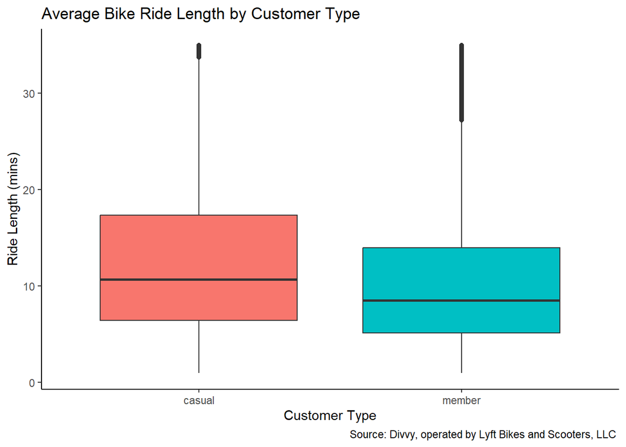

```r
ride_length_plot <- ggplot(bdfinal, aes(x = member_casual, y = ride_length, fill = member_casual)) +
   geom_boxplot() +
   guides(fill = "none") +
   labs(
      title = "Average Bike Ride Length by Customer Type",
      caption = "Source: Divvy, operated by Lyft Bikes and Scooters, LLC ",
      x = "Customer Type",
      y = "Ride Length (mins)"
    ) +
   theme_classic()
ride_length_plot
```

```r
ggsave("problem1.jpeg")
```

## Calculated the days of the week for date and time each trip started and dispensed the results in a new column, dotwstart.

```r
bdfinal$dotw_start <- weekdays(bdfinal$started_at)
head(bdfinal)
```

```
##            ride_id rideable_type          started_at            ended_at
## 1 4422E707103AA4FF electric_bike 2024-10-14 03:26:04 2024-10-14 03:32:56
## 2 19DB722B44CBE82F electric_bike 2024-10-13 19:33:38 2024-10-13 19:39:04
## 3 20AE2509FD68C939 electric_bike 2024-10-13 23:40:48 2024-10-13 23:48:02
## 4 D0F17580AB9515A9 electric_bike 2024-10-14 02:13:41 2024-10-14 02:25:40
## 5 A114A483941288D1 electric_bike 2024-10-13 19:26:41 2024-10-13 19:28:18
## 6 97833F00E6A67DC6 electric_bike 2024-10-14 06:35:06 2024-10-14 06:42:10
##   start_station_name end_station_name start_lat start_lng end_lat end_lng
## 1                                         41.96    -87.65   41.98  -87.67
## 2                                         41.98    -87.67   41.97  -87.66
## 3                                         41.97    -87.66   41.95  -87.65
## 4                                         41.95    -87.65   41.96  -87.65
## 5                                         41.98    -87.67   41.98  -87.67
## 6                                         41.88    -87.65   41.89  -87.64
##   member_casual ride_length dotw_start
## 1        member        6.87     Monday
## 2        member        5.43     Sunday
## 3        member        7.23     Sunday
## 4        member       11.97     Monday
## 5        member        1.62     Sunday
## 6        member        7.08     Monday
```

## Redid the individual casual and member data sets to include the new dotw_start field. Got the mode of days of the week for both casual and member riders.

```r
casualset <- bdfinal[bdfinal$member_casual == "casual", ]
memberset <- bdfinal[bdfinal$member_casual == "member", ]

cdayset1 <- subset(casualset, select=c(dotw_start))
mdayset1 <- subset(memberset, select=c(dotw_start))

casualdaymode <- get_mode(cdayset1$dotw_start)
print(casualdaymode)
```

```
## [1] "Saturday"
```

```r
memberdaymode <- get_mode(mdayset1$dotw_start)
print(memberdaymode)
```

```
## [1] "Wednesday"
```

## Created a pipe/summary table of the average ride length per day of the week for both casual and member riders.

```r
dotw_stats1 <- bdfinal %>%
  group_by(member_casual, dotw_start) %>%
  summarize(avg_ride_length = round(mean(ride_length), 2), .groups = 'keep') %>%
  mutate(dotw_start = factor(dotw_start, levels = c("Sunday", "Monday", "Tuesday", "Wednesday", "Thursday", "Friday", "Saturday"))) %>%
  arrange(member_casual, dotw_start)
dotw_stats1
```

```
## # A tibble: 14 × 3
## # Groups:   member_casual, dotw_start [14]
##    member_casual dotw_start avg_ride_length
##    <chr>         <fct>                <dbl>
##  1 casual        Sunday                13.8
##  2 casual        Monday                12.1
##  3 casual        Tuesday               11.7
##  4 casual        Wednesday             11.9
##  5 casual        Thursday              11.8
##  6 casual        Friday                12.5
##  7 casual        Saturday              13.9
##  8 member        Sunday                11.1
##  9 member        Monday                10.1
## 10 member        Tuesday               10.3
## 11 member        Wednesday             10.4
## 12 member        Thursday              10.3
## 13 member        Friday                10.3
## 14 member        Saturday              11.2
```

## Created a pipe/summary table for additional statistics on days of the week for casual riders.

```r
cdayset2 <- subset(casualset, select=c(dotw_start, ride_length))

cdotw_stats <- cdayset2 %>%
  group_by(dotw_start) %>%
  mutate(dotw_start = factor(dotw_start, levels = c("Sunday", "Monday", "Tuesday", "Wednesday", "Thursday", "Friday", "Saturday"))) %>%
  summarise(min_ride_length = min(ride_length),
            max_ride_length = max(ride_length),
            average_ride_length = round(mean(ride_length), 2),
            median_ride_length = median(ride_length),
            mode_ride_length = get_mode(ride_length),
            ride_length_25_quantile = quantile(ride_length, 0.25),
            ride_length_75_quantile = quantile(ride_length, 0.75),
            ride_length_IQR = IQR(ride_length),
            ride_length_sd = round(sd(ride_length), 2),
            ride_length_var = round(var(ride_length), 2))
print(cdotw_stats)
```

```
## # A tibble: 7 × 11
##   dotw_start min_ride_length max_ride_length average_ride_length
##   <fct>                <dbl>           <dbl>               <dbl>
## 1 Sunday                   1            35.0                13.8
## 2 Monday                   1            35.0                12.1
## 3 Tuesday                  1            35.0                11.7
## 4 Wednesday                1            35.0                11.9
## 5 Thursday                 1            35.0                11.8
## 6 Friday                   1            35.0                12.5
## 7 Saturday                 1            35.0                13.9
## # ℹ 7 more variables: median_ride_length <dbl>, mode_ride_length <dbl>,
## #   ride_length_25_quantile <dbl>, ride_length_75_quantile <dbl>,
## #   ride_length_IQR <dbl>, ride_length_sd <dbl>, ride_length_var <dbl>
```

## Created a pipe/summary table for additional statistics on days of the week for member riders.

```r
mdayset2 <- subset(memberset, select=c(dotw_start, ride_length))

mdotw_stats <- mdayset2 %>%
  group_by(dotw_start) %>%
  mutate(dotw_start = factor(dotw_start, levels = c("Sunday", "Monday", "Tuesday", "Wednesday", "Thursday", "Friday", "Saturday"))) %>%
  summarise(min_ride_length = min(ride_length),
            max_ride_length = max(ride_length),
            average_ride_length = round(mean(ride_length), 2),
            median_ride_length = median(ride_length),
            mode_ride_length = get_mode(ride_length),
            ride_length_25_quantile = quantile(ride_length, 0.25),
            ride_length_75_quantile = quantile(ride_length, 0.75),
            ride_length_IQR = IQR(ride_length),
            ride_length_sd = round(sd(ride_length), 2),
            ride_length_var = round(var(ride_length), 2))
print(mdotw_stats)
```

```
## # A tibble: 7 × 11
##   dotw_start min_ride_length max_ride_length average_ride_length
##   <fct>                <dbl>           <dbl>               <dbl>
## 1 Sunday                   1            35.0                11.1
## 2 Monday                   1            35.0                10.1
## 3 Tuesday                  1            35.0                10.3
## 4 Wednesday                1            35.0                10.4
## 5 Thursday                 1            35.0                10.3
## 6 Friday                   1            35.0                10.3
## 7 Saturday                 1            35.0                11.2
## # ℹ 7 more variables: median_ride_length <dbl>, mode_ride_length <dbl>,
## #   ride_length_25_quantile <dbl>, ride_length_75_quantile <dbl>,
## #   ride_length_IQR <dbl>, ride_length_sd <dbl>, ride_length_var <dbl>
```

## Created a pipe of ride length per day of the week for both casual and member riders, with ordered days of the week, to create a box plot.

```r
dotw_stats2 <- bdfinal %>%
  mutate(dotw_start = factor(dotw_start, levels = c("Sunday", "Monday", "Tuesday", "Wednesday", "Thursday", "Friday", "Saturday")))
head(dotw_stats2)
```

```
##            ride_id rideable_type          started_at            ended_at
## 1 4422E707103AA4FF electric_bike 2024-10-14 03:26:04 2024-10-14 03:32:56
## 2 19DB722B44CBE82F electric_bike 2024-10-13 19:33:38 2024-10-13 19:39:04
## 3 20AE2509FD68C939 electric_bike 2024-10-13 23:40:48 2024-10-13 23:48:02
## 4 D0F17580AB9515A9 electric_bike 2024-10-14 02:13:41 2024-10-14 02:25:40
## 5 A114A483941288D1 electric_bike 2024-10-13 19:26:41 2024-10-13 19:28:18
## 6 97833F00E6A67DC6 electric_bike 2024-10-14 06:35:06 2024-10-14 06:42:10
##   start_station_name end_station_name start_lat start_lng end_lat end_lng
## 1                                         41.96    -87.65   41.98  -87.67
## 2                                         41.98    -87.67   41.97  -87.66
## 3                                         41.97    -87.66   41.95  -87.65
## 4                                         41.95    -87.65   41.96  -87.65
## 5                                         41.98    -87.67   41.98  -87.67
## 6                                         41.88    -87.65   41.89  -87.64
##   member_casual ride_length dotw_start
## 1        member        6.87     Monday
## 2        member        5.43     Sunday
## 3        member        7.23     Sunday
## 4        member       11.97     Monday
## 5        member        1.62     Sunday
## 6        member        7.08     Monday
```

## Created a box plot for average ride length per day of the week for both casual riders and member riders.

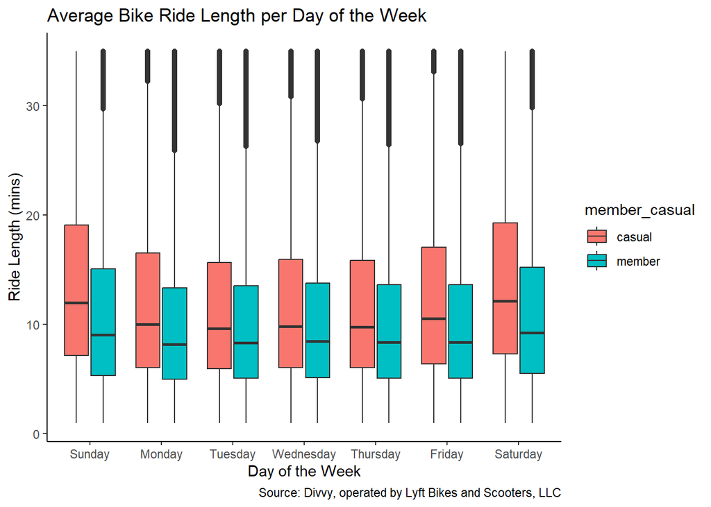

```r
week_length_plot <- ggplot(dotw_stats2, aes(x = dotw_start, y = ride_length, fill = member_casual)) +
  geom_boxplot() +
  labs(
    title = "Average Bike Ride Length per Day of the Week",
    caption = "Source: Divvy, operated by Lyft Bikes and Scooters, LLC",
    x = "Day of the Week",
    y = "Ride Length (mins)"
  ) +
  theme_classic()
week_length_plot
```

```r
ggsave("problem2a.jpeg")
```

## Created a pipe/summary table of the total number of rides per day of the week for both casual and annual members.

```r
dotw_stats3 <- bdfinal %>%
  group_by(member_casual) %>%
  count(dotw_start, name = "n_rides") %>%
  mutate(dotw_start = factor(dotw_start, levels = c("Sunday", "Monday", "Tuesday", "Wednesday", "Thursday", "Friday", "Saturday"))) %>%
  arrange(member_casual, dotw_start)
dotw_stats3
```

```
## # A tibble: 14 × 3
## # Groups:   member_casual [2]
##    member_casual dotw_start n_rides
##    <chr>         <fct>        <int>
##  1 casual        Sunday      290500
##  2 casual        Monday      210848
##  3 casual        Tuesday     202113
##  4 casual        Wednesday   238748
##  5 casual        Thursday    240810
##  6 casual        Friday      266538
##  7 casual        Saturday    355902
##  8 member        Sunday      385137
##  9 member        Monday      502825
## 10 member        Tuesday     541674
## 11 member        Wednesday   598504
## 12 member        Thursday    574124
## 13 member        Friday      501160
## 14 member        Saturday    448787
```

## Created a bar graph for total number of rides per day of the week for both casual riders and member riders.

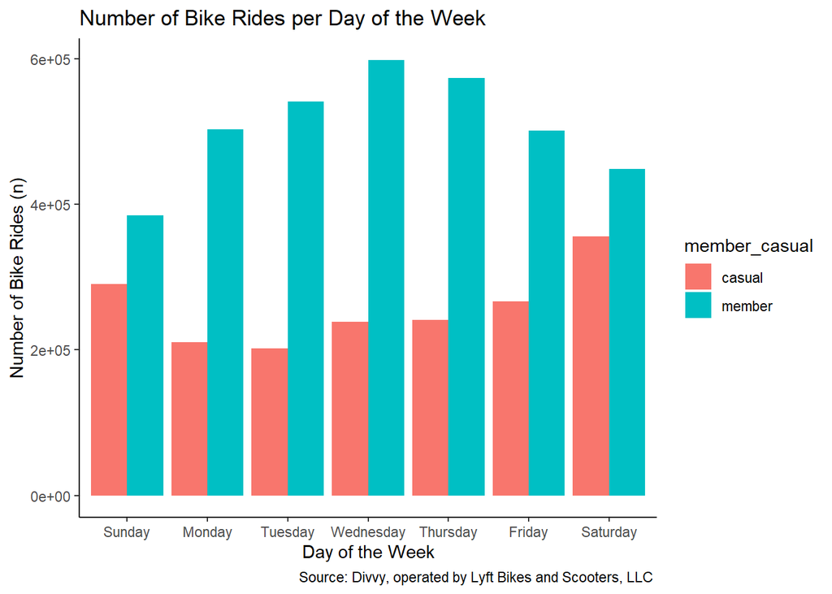

```r
week_num_plot <- ggplot(dotw_stats3, aes(x = dotw_start, y = n_rides, fill = member_casual)) +
   geom_bar(stat = "identity", position = "dodge") +
   labs(
      title = "Number of Bike Rides per Day of the Week",
      caption = "Source: Divvy, operated by Lyft Bikes and Scooters, LLC ",
      x = "Day of the Week",
      y = "Number of Bike Rides (n)"
    ) +
   theme_classic()
week_num_plot
```

```r
ggsave("problem2b.jpeg")
```

## Calculated the month of the year for date and time each trip started and dispensed the results in a new column, moty_start.

```r
bdfinal$moty_start <- format(bdfinal$started_at, "%b")
head(bdfinal)
```

```
##            ride_id rideable_type          started_at            ended_at
## 1 4422E707103AA4FF electric_bike 2024-10-14 03:26:04 2024-10-14 03:32:56
## 2 19DB722B44CBE82F electric_bike 2024-10-13 19:33:38 2024-10-13 19:39:04
## 3 20AE2509FD68C939 electric_bike 2024-10-13 23:40:48 2024-10-13 23:48:02
## 4 D0F17580AB9515A9 electric_bike 2024-10-14 02:13:41 2024-10-14 02:25:40
## 5 A114A483941288D1 electric_bike 2024-10-13 19:26:41 2024-10-13 19:28:18
## 6 97833F00E6A67DC6 electric_bike 2024-10-14 06:35:06 2024-10-14 06:42:10
##   start_station_name end_station_name start_lat start_lng end_lat end_lng
## 1                                         41.96    -87.65   41.98  -87.67
## 2                                         41.98    -87.67   41.97  -87.66
## 3                                         41.97    -87.66   41.95  -87.65
## 4                                         41.95    -87.65   41.96  -87.65
## 5                                         41.98    -87.67   41.98  -87.67
## 6                                         41.88    -87.65   41.89  -87.64
##   member_casual ride_length dotw_start moty_start
## 1        member        6.87     Monday        Oct
## 2        member        5.43     Sunday        Oct
## 3        member        7.23     Sunday        Oct
## 4        member       11.97     Monday        Oct
## 5        member        1.62     Sunday        Oct
## 6        member        7.08     Monday        Oct
```

## Calculated the season of the year for date and time each trip started and dispensed the results in a new column, soty_start.

```r
bdfinal <- bdfinal %>%
  mutate(soty_start = case_when(
    bdfinal$moty_start %in% c('Dec', 'Jan', 'Feb') ~ 'Winter',
    bdfinal$moty_start %in% c('Mar', 'Apr', 'May') ~ 'Spring',
    bdfinal$moty_start %in% c('Jun', 'Jul', 'Aug') ~ 'Summer',
    bdfinal$moty_start %in% c('Sep', 'Oct', 'Nov') ~ 'Fall'))
head(bdfinal)
```

```
##            ride_id rideable_type          started_at            ended_at
## 1 4422E707103AA4FF electric_bike 2024-10-14 03:26:04 2024-10-14 03:32:56
## 2 19DB722B44CBE82F electric_bike 2024-10-13 19:33:38 2024-10-13 19:39:04
## 3 20AE2509FD68C939 electric_bike 2024-10-13 23:40:48 2024-10-13 23:48:02
## 4 D0F17580AB9515A9 electric_bike 2024-10-14 02:13:41 2024-10-14 02:25:40
## 5 A114A483941288D1 electric_bike 2024-10-13 19:26:41 2024-10-13 19:28:18
## 6 97833F00E6A67DC6 electric_bike 2024-10-14 06:35:06 2024-10-14 06:42:10
##   start_station_name end_station_name start_lat start_lng end_lat end_lng
## 1                                         41.96    -87.65   41.98  -87.67
## 2                                         41.98    -87.67   41.97  -87.66
## 3                                         41.97    -87.66   41.95  -87.65
## 4                                         41.95    -87.65   41.96  -87.65
## 5                                         41.98    -87.67   41.98  -87.67
## 6                                         41.88    -87.65   41.89  -87.64
##   member_casual ride_length dotw_start moty_start soty_start
## 1        member        6.87     Monday        Oct       Fall
## 2        member        5.43     Sunday        Oct       Fall
## 3        member        7.23     Sunday        Oct       Fall
## 4        member       11.97     Monday        Oct       Fall
## 5        member        1.62     Sunday        Oct       Fall
## 6        member        7.08     Monday        Oct       Fall
```

## Redid the individual casual and member data sets to include the new moty_start and soty_start fields. Got the mode of season of the year for both casual and member riders.

```r
casualset <- bdfinal[bdfinal$member_casual == "casual", ]
memberset <- bdfinal[bdfinal$member_casual == "member", ]

cseasonset1 <- subset(casualset, select=c(soty_start))
mseasonset1 <- subset(memberset, select=c(soty_start))

casualseasonmode <- get_mode(cseasonset1$soty_start)
print(casualseasonmode)
```

```
## [1] "Summer"
```

```r
memberseasonmode <- get_mode(mseasonset1$soty_start)
print(memberseasonmode)
```

```
## [1] "Summer"
```

```r
soty_stats1 <- bdfinal %>%
  group_by(member_casual, soty_start) %>%
  summarize(avg_ride_length = round(mean(ride_length), 2), .groups = 'keep') %>%
  mutate(soty_start = factor(soty_start, levels = c("Spring", "Summer", "Fall", "Winter"))) %>%
  arrange(member_casual, soty_start)
soty_stats1
```

```
## # A tibble: 8 × 3
## # Groups:   member_casual, soty_start [8]
##   member_casual soty_start avg_ride_length
##   <chr>         <fct>                <dbl>
## 1 casual        Spring               12.8
## 2 casual        Summer               13.5
## 3 casual        Fall                 11.9
## 4 casual        Winter               10.3
## 5 member        Spring               10.4
## 6 member        Summer               11.2
## 7 member        Fall                 10.2
## 8 member        Winter                9.43
```

## Created a pipe/summary table for additional statistics on season of the year for casual riders.

```r
cseasonset2 <- subset(casualset, select=c(soty_start, ride_length))

csoty_stats <- cseasonset2 %>%
  group_by(soty_start) %>%
  mutate(soty_start = factor(soty_start, levels = c("Spring", "Summer", "Fall", "Winter"))) %>%
  summarise(min_ride_length = min(ride_length),
            max_ride_length = max(ride_length),
            average_ride_length = round(mean(ride_length), 2),
            median_ride_length = median(ride_length),
            mode_ride_length = get_mode(ride_length),
            ride_length_25_quantile = quantile(ride_length, 0.25),
            ride_length_75_quantile = quantile(ride_length, 0.75),
            ride_length_IQR = IQR(ride_length),
            ride_length_sd = round(sd(ride_length), 2),
            ride_length_var = round(var(ride_length), 2))
print(csoty_stats)
```

```
## # A tibble: 4 × 11
##   soty_start min_ride_length max_ride_length average_ride_length
##   <fct>                <dbl>           <dbl>               <dbl>
## 1 Spring                   1            35.0                12.8
## 2 Summer                   1            35.0                13.5
## 3 Fall                     1            35.0                11.9
## 4 Winter                   1            35.0                10.3
## # ℹ 7 more variables: median_ride_length <dbl>, mode_ride_length <dbl>,
## #   ride_length_25_quantile <dbl>, ride_length_75_quantile <dbl>,
## #   ride_length_IQR <dbl>, ride_length_sd <dbl>, ride_length_var <dbl>
```

## Created a pipe/summary table for additional statistics on season of the year for member riders.

```r
mseasonset2 <- subset(memberset, select=c(soty_start, ride_length))

msoty_stats <- mseasonset2 %>%
  group_by(soty_start) %>%
  mutate(soty_start = factor(soty_start, levels = c("Spring", "Summer", "Fall", "Winter"))) %>%
  summarise(min_ride_length = min(ride_length),
            max_ride_length = max(ride_length),
            average_ride_length = round(mean(ride_length), 2),
            median_ride_length = median(ride_length),
            mode_ride_length = get_mode(ride_length),
            ride_length_25_quantile = quantile(ride_length, 0.25),
            ride_length_75_quantile = quantile(ride_length, 0.75),
            ride_length_IQR = IQR(ride_length),
            ride_length_sd = round(sd(ride_length), 2),
            ride_length_var = round(var(ride_length), 2))
print(msoty_stats)
```

```
## # A tibble: 4 × 11
##   soty_start min_ride_length max_ride_length average_ride_length
##   <fct>                <dbl>           <dbl>               <dbl>
## 1 Spring                   1            35.0               10.4
## 2 Summer                   1            35.0               11.2
## 3 Fall                     1            35.0               10.2
## 4 Winter                   1            35.0                9.43
## # ℹ 7 more variables: median_ride_length <dbl>, mode_ride_length <dbl>,
## #   ride_length_25_quantile <dbl>, ride_length_75_quantile <dbl>,
## #   ride_length_IQR <dbl>, ride_length_sd <dbl>, ride_length_var <dbl>
```

## Created a pipe of the ride length per season of the year for both casual and annual members, with ordered seasons of the year, to create a box plot.

```r
soty_stats2 <- bdfinal %>%
  mutate(soty_start = factor(soty_start, levels = c("Spring", "Summer", "Fall", "Winter")))
head(soty_stats2)
```

```
##            ride_id rideable_type          started_at            ended_at
## 1 4422E707103AA4FF electric_bike 2024-10-14 03:26:04 2024-10-14 03:32:56
## 2 19DB722B44CBE82F electric_bike 2024-10-13 19:33:38 2024-10-13 19:39:04
## 3 20AE2509FD68C939 electric_bike 2024-10-13 23:40:48 2024-10-13 23:48:02
## 4 D0F17580AB9515A9 electric_bike 2024-10-14 02:13:41 2024-10-14 02:25:40
## 5 A114A483941288D1 electric_bike 2024-10-13 19:26:41 2024-10-13 19:28:18
## 6 97833F00E6A67DC6 electric_bike 2024-10-14 06:35:06 2024-10-14 06:42:10
##   start_station_name end_station_name start_lat start_lng end_lat end_lng
## 1                                         41.96    -87.65   41.98  -87.67
## 2                                         41.98    -87.67   41.97  -87.66
## 3                                         41.97    -87.66   41.95  -87.65
## 4                                         41.95    -87.65   41.96  -87.65
## 5                                         41.98    -87.67   41.98  -87.67
## 6                                         41.88    -87.65   41.89  -87.64
##   member_casual ride_length dotw_start moty_start soty_start
## 1        member        6.87     Monday        Oct       Fall
## 2        member        5.43     Sunday        Oct       Fall
## 3        member        7.23     Sunday        Oct       Fall
## 4        member       11.97     Monday        Oct       Fall
## 5        member        1.62     Sunday        Oct       Fall
## 6        member        7.08     Monday        Oct       Fall
```

## Created a box plot for average ride length per season of the year for both casual riders and member riders.

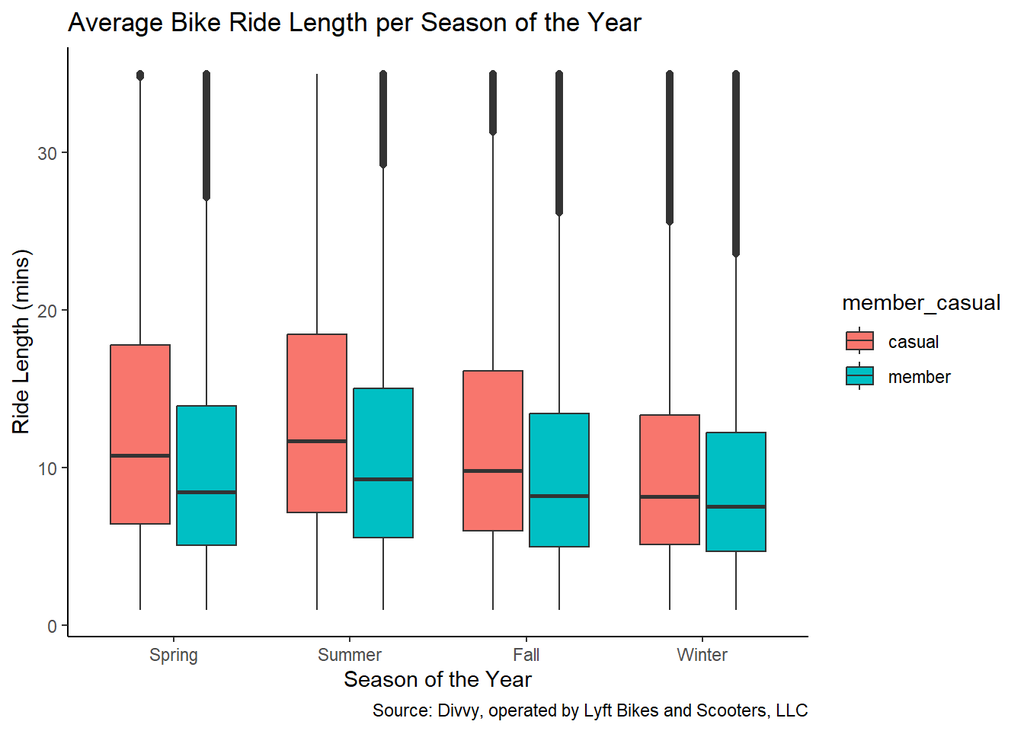

```r
season_length_plot <- ggplot(soty_stats2, aes(x = soty_start, y = ride_length, fill = member_casual)) +
  geom_boxplot() +
  labs(
    title = "Average Bike Ride Length per Season of the Year",
    caption = "Source: Divvy, operated by Lyft Bikes and Scooters, LLC",
    x = "Season of the Year",
    y = "Ride Length (mins)"
  ) +
  theme_classic()
season_length_plot
```

```r
ggsave("problem3a.jpeg")
```

## Created a pipe/summary table of the number of rides per season of the year for both casual and annual members.

```r
soty_stats3 <- bdfinal %>%
  group_by(member_casual) %>%
  count(soty_start, name = "n_rides") %>%
  mutate(soty_start = factor(soty_start, levels = c("Spring", "Summer", "Fall", "Winter"))) %>%
  arrange(member_casual, soty_start)
soty_stats3
```

```
## # A tibble: 8 × 3
## # Groups:   member_casual [2]
##   member_casual soty_start n_rides
##   <chr>         <fct>        <int>
## 1 casual        Spring      363368
## 2 casual        Summer      763139
## 3 casual        Fall        567795
## 4 casual        Winter      111157
## 5 member        Spring      826969
## 6 member        Summer     1197056
## 7 member        Fall       1082923
## 8 member        Winter      445263
```

## Created a bar graph for total number of rides per season of the year for both casual riders and member riders.

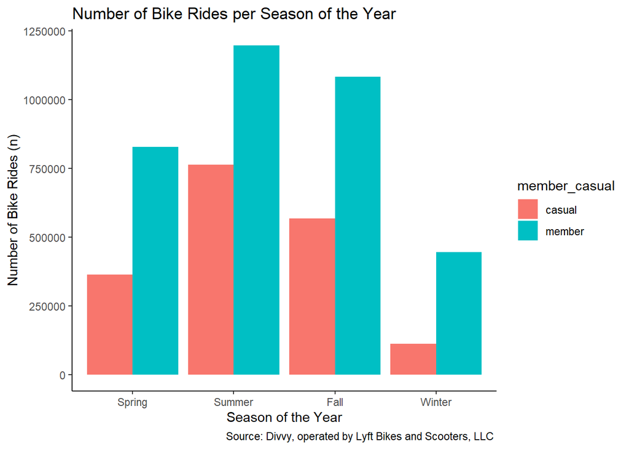

```r
season_num_plot <- ggplot(soty_stats3, aes(x = soty_start, y = n_rides, fill = member_casual)) +
   geom_bar(stat = "identity", position = "dodge") +
   labs(
      title = "Number of Bike Rides per Season of the Year",
      caption = "Source: Divvy, operated by Lyft Bikes and Scooters, LLC ",
      x = "Season of the Year",
      y = "Number of Bike Rides (n)"
    ) +
   theme_classic()
season_num_plot
```

```r
ggsave("problem3b.jpeg")
```

## Got the mode of months of the year for both casual and member riders.

```r
cmonthset1 <- subset(casualset, select=c(moty_start))
mmonthset1 <- subset(memberset, select=c(moty_start))

casualmonthmode <- get_mode(cmonthset1$moty_start)
print(casualmonthmode)
```

```
## [1] "Sep"
```

```r
membermonthmode <- get_mode(mmonthset1$moty_start)
print(membermonthmode)
```

```
## [1] "Sep"
```

## Created a pipe/summary table of the average ride length per month of the year for both casual and member riders.

```r
moty_stats1 <- bdfinal %>%
  group_by(member_casual, moty_start) %>%
  summarize(avg_ride_length = round(mean(ride_length), 2), .groups = 'keep') %>%
  mutate(moty_start = factor(moty_start, levels = c("Jan", "Feb", "Mar", "Apr", "May", "Jun", "Jul", "Aug", "Sep", "Oct", "Nov", "Dec"))) %>%
  arrange(member_casual, moty_start)
moty_stats1
```

```
## # A tibble: 24 × 3
## # Groups:   member_casual, moty_start [24]
##    member_casual moty_start avg_ride_length
##    <chr>         <fct>                <dbl>
##  1 casual        Jan                   9.23
##  2 casual        Feb                  11.0
##  3 casual        Mar                  11.9
##  4 casual        Apr                  12.5
##  5 casual        May                  13.4
##  6 casual        Jun                  13.6
##  7 casual        Jul                  13.6
##  8 casual        Aug                  13.3
##  9 casual        Sep                  12.1
## 10 casual        Oct                  12.1
## # ℹ 14 more rows
```

## Created a pipe/summary table for additional statistics on months of the year for casual riders.

```r
cmonthset2 <- subset(casualset, select=c(moty_start, ride_length))

cmoty_stats <- cmonthset2 %>%
  group_by(moty_start) %>%
  mutate(moty_start = factor(moty_start, levels = c("Jan", "Feb", "Mar", "Apr", "May", "Jun", "Jul", "Aug", "Sep", "Oct", "Nov", "Dec"))) %>%
  summarise(min_ride_length = min(ride_length),
            max_ride_length = max(ride_length),
            average_ride_length = round(mean(ride_length), 2),
            median_ride_length = median(ride_length),
            mode_ride_length = get_mode(ride_length),
            ride_length_25_quantile = quantile(ride_length, 0.25),
            ride_length_75_quantile = quantile(ride_length, 0.75),
            ride_length_IQR = IQR(ride_length),
            ride_length_sd = round(sd(ride_length), 2),
            ride_length_var = round(var(ride_length), 2))
print(cmoty_stats)
```

```
## # A tibble: 12 × 11
##    moty_start min_ride_length max_ride_length average_ride_length
##    <fct>                <dbl>           <dbl>               <dbl>
##  1 Jan                      1            35.0                9.23
##  2 Feb                      1            35.0               11.0
##  3 Mar                      1            35.0               11.9
##  4 Apr                      1            35.0               12.5
##  5 May                      1            35.0               13.4
##  6 Jun                      1            35.0               13.6
##  7 Jul                      1            35.0               13.6
##  8 Aug                      1            35.0               13.3
##  9 Sep                      1            35.0               12.1
## 10 Oct                      1            35.0               12.1
## 11 Nov                      1            35.0               10.8
## 12 Dec                      1            35.0               10.2
## # ℹ 7 more variables: median_ride_length <dbl>, mode_ride_length <dbl>,
## #   ride_length_25_quantile <dbl>, ride_length_75_quantile <dbl>,
## #   ride_length_IQR <dbl>, ride_length_sd <dbl>, ride_length_var <dbl>
```

## Created a pipe/summary table for additional statistics on months of the year for member riders.

```r
mmonthset2 <- subset(memberset, select=c(moty_start, ride_length))

mmoty_stats <- mmonthset2 %>%
  group_by(moty_start) %>%
  mutate(moty_start = factor(moty_start, levels = c("Jan", "Feb", "Mar", "Apr", "May", "Jun", "Jul", "Aug", "Sep", "Oct", "Nov", "Dec"))) %>%
  summarise(min_ride_length = min(ride_length),
            max_ride_length = max(ride_length),
            average_ride_length = round(mean(ride_length), 2),
            median_ride_length = median(ride_length),
            mode_ride_length = get_mode(ride_length),
            ride_length_25_quantile = quantile(ride_length, 0.25),
            ride_length_75_quantile = quantile(ride_length, 0.75),
            ride_length_IQR = IQR(ride_length),
            ride_length_sd = round(sd(ride_length), 2),
            ride_length_var = round(var(ride_length), 2))
print(mmoty_stats)
```

```
## # A tibble: 12 × 11
##    moty_start min_ride_length max_ride_length average_ride_length
##    <fct>                <dbl>           <dbl>               <dbl>
##  1 Jan                      1            35.0                9.02
##  2 Feb                      1            35.0                9.8
##  3 Mar                      1            35.0                9.79
##  4 Apr                      1            35.0               10.2
##  5 May                      1            35.0               11.0
##  6 Jun                      1            35.0               11.3
##  7 Jul                      1            35.0               11.2
##  8 Aug                      1            35.0               11.0
##  9 Sep                      1            35.0               10.5
## 10 Oct                      1            35.0               10.2
## 11 Nov                      1            35.0                9.6
## 12 Dec                      1            35.0                9.35
## # ℹ 7 more variables: median_ride_length <dbl>, mode_ride_length <dbl>,
## #   ride_length_25_quantile <dbl>, ride_length_75_quantile <dbl>,
## #   ride_length_IQR <dbl>, ride_length_sd <dbl>, ride_length_var <dbl>
```

## Created a pipe of the ride length per month of the year for both casual and annual members, with ordered months of the year, to create a box plot.

```r
moty_stats2 <- bdfinal %>%
  mutate(moty_start = factor(moty_start, levels = c("Jan", "Feb", "Mar", "Apr", "May", "Jun", "Jul", "Aug", "Sep", "Oct", "Nov", "Dec")))
head(moty_stats2)
```

```
##            ride_id rideable_type          started_at            ended_at
## 1 4422E707103AA4FF electric_bike 2024-10-14 03:26:04 2024-10-14 03:32:56
## 2 19DB722B44CBE82F electric_bike 2024-10-13 19:33:38 2024-10-13 19:39:04
## 3 20AE2509FD68C939 electric_bike 2024-10-13 23:40:48 2024-10-13 23:48:02
## 4 D0F17580AB9515A9 electric_bike 2024-10-14 02:13:41 2024-10-14 02:25:40
## 5 A114A483941288D1 electric_bike 2024-10-13 19:26:41 2024-10-13 19:28:18
## 6 97833F00E6A67DC6 electric_bike 2024-10-14 06:35:06 2024-10-14 06:42:10
##   start_station_name end_station_name start_lat start_lng end_lat end_lng
## 1                                         41.96    -87.65   41.98  -87.67
## 2                                         41.98    -87.67   41.97  -87.66
## 3                                         41.97    -87.66   41.95  -87.65
## 4                                         41.95    -87.65   41.96  -87.65
## 5                                         41.98    -87.67   41.98  -87.67
## 6                                         41.88    -87.65   41.89  -87.64
##   member_casual ride_length dotw_start moty_start soty_start
## 1        member        6.87     Monday        Oct       Fall
## 2        member        5.43     Sunday        Oct       Fall
## 3        member        7.23     Sunday        Oct       Fall
## 4        member       11.97     Monday        Oct       Fall
## 5        member        1.62     Sunday        Oct       Fall
## 6        member        7.08     Monday        Oct       Fall
```

## Created a box plot for average ride length per month of the year for both casual riders and member riders.

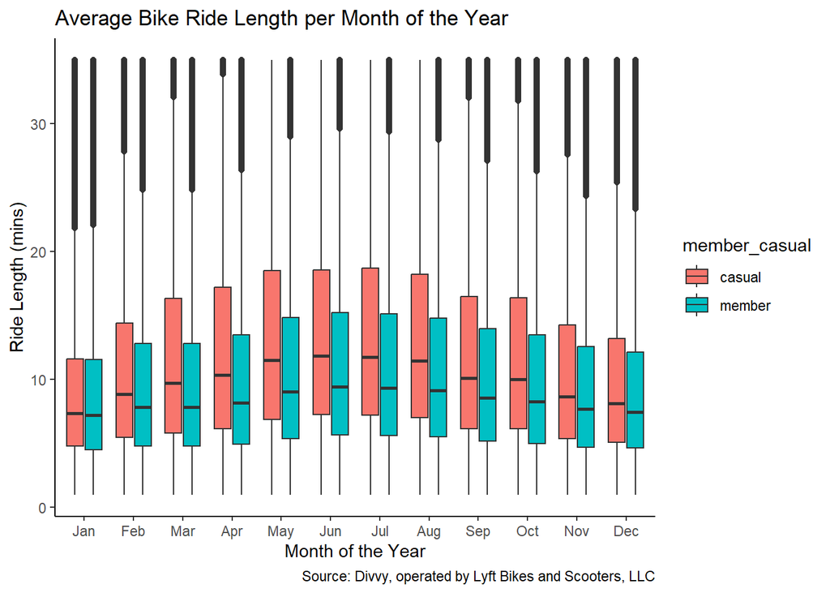

```r
month_length_plot <- ggplot(moty_stats2, aes(x = moty_start, y = ride_length, fill = member_casual)) +
  geom_boxplot() +
  labs(
    title = "Average Bike Ride Length per Month of the Year",
    caption = "Source: Divvy, operated by Lyft Bikes and Scooters, LLC",
    x = "Month of the Year",
    y = "Ride Length (mins)"
  ) +
  theme_classic()
month_length_plot
```

```r
ggsave("problem4a.jpeg")
```

## Created a pipe/summary table of the number of rides per month of the year for both casual and annual members.

```r
moty_stats3 <- bdfinal %>%
  group_by(member_casual) %>%
  count(moty_start, name = "n_rides") %>%
  mutate(moty_start = factor(moty_start, levels = c("Jan", "Feb", "Mar", "Apr", "May", "Jun", "Jul", "Aug", "Sep", "Oct", "Nov", "Dec"))) %>%
  arrange(member_casual, moty_start)
moty_stats3
```

```
## # A tibble: 24 × 3
## # Groups:   member_casual [2]
##    member_casual moty_start n_rides
##    <chr>         <fct>        <int>
##  1 casual        Jan          22478
##  2 casual        Feb          41409
##  3 casual        Mar          70235
##  4 casual        Apr         108277
##  5 casual        May         184856
##  6 casual        Jun         244131
##  7 casual        Jul         257447
##  8 casual        Aug         261561
##  9 casual        Sep         295363
## 10 casual        Oct         184041
## # ℹ 14 more rows
```

## Created a bar graph for total number of rides per month of the year for both casual riders and member riders.

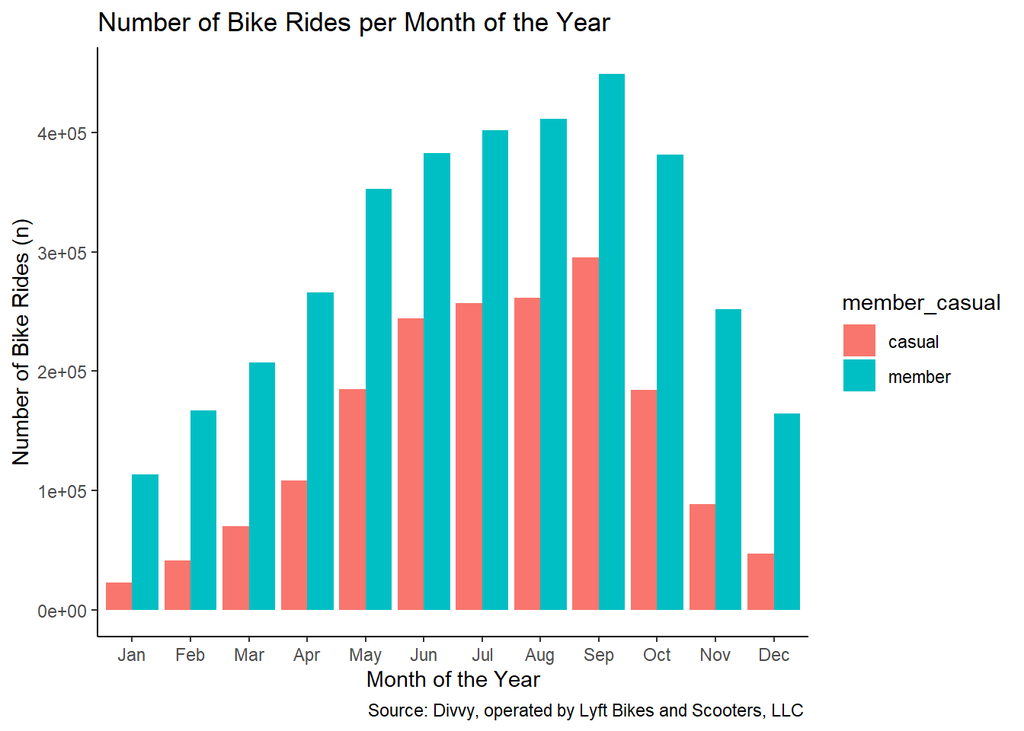

```r
month_num_plot <- ggplot(moty_stats3, aes(x = moty_start, y = n_rides, fill = member_casual)) +
   geom_bar(stat = "identity", position = "dodge") +
   labs(
      title = "Number of Bike Rides per Month of the Year",
      caption = "Source: Divvy, operated by Lyft Bikes and Scooters, LLC ",
      x = "Month of the Year",
      y = "Number of Bike Rides (n)"
    ) +
   theme_classic()
month_num_plot
```

```r
ggsave("problem4b.jpeg")
```

```r
ctypeset1 <- subset(casualset, select=c(rideable_type ))
mtypeset1 <- subset(memberset, select=c(rideable_type ))

casualtypemode <- get_mode(ctypeset1$rideable_type )
print(casualtypemode)
```

```
## [1] "electric_bike"
```

```r
membertypemode <- get_mode(ctypeset1$rideable_type )
print(membertypemode)
```

```
## [1] "electric_bike"
```

## Created a pipe/summary table of the average ride length per bike type for both casual and annual members.

```r
type_stats1 <- bdfinal %>%
  group_by(member_casual, rideable_type) %>%
  summarize(avg_ride_length = round(mean(ride_length), 2), .groups = 'keep') %>%
  arrange(member_casual, rideable_type)
type_stats1
```

```
## # A tibble: 6 × 3
## # Groups:   member_casual, rideable_type [6]
##   member_casual rideable_type    avg_ride_length
##   <chr>         <chr>                      <dbl>
## 1 casual        classic_bike               14.3
## 2 casual        electric_bike              11.5
## 3 casual        electric_scooter           10.3
## 4 member        classic_bike               10.9
## 5 member        electric_bike              10.1
## 6 member        electric_scooter            8.38
```

## Created a pipe/summary table for additional statistics on bike type for casual riders.

```r
ctypeset2 <- subset(casualset, select=c(rideable_type, ride_length))

ctype_stats <- ctypeset2 %>%
  group_by(rideable_type) %>%
  summarise(min_ride_length = min(ride_length),
            max_ride_length = max(ride_length),
            average_ride_length = round(mean(ride_length), 2),
            median_ride_length = median(ride_length),
            mode_ride_length = get_mode(ride_length),
            ride_length_25_quantile = quantile(ride_length, 0.25),
            ride_length_75_quantile = quantile(ride_length, 0.75),
            ride_length_IQR = IQR(ride_length),
            ride_length_sd = round(sd(ride_length), 2),
            ride_length_var = round(var(ride_length), 2))
print(ctype_stats)
```

```
## # A tibble: 3 × 11
##   rideable_type    min_ride_length max_ride_length average_ride_length
##   <chr>                      <dbl>           <dbl>               <dbl>
## 1 classic_bike                   1            35.0                14.3
## 2 electric_bike                  1            35.0                11.5
## 3 electric_scooter               1            35.0                10.3
## # ℹ 7 more variables: median_ride_length <dbl>, mode_ride_length <dbl>,
## #   ride_length_25_quantile <dbl>, ride_length_75_quantile <dbl>,
## #   ride_length_IQR <dbl>, ride_length_sd <dbl>, ride_length_var <dbl>
```

```r
mtypeset2 <- subset(memberset, select=c(rideable_type, ride_length))

mtype_stats <- mtypeset2 %>%
  group_by(rideable_type) %>%
  summarise(min_ride_length = min(ride_length),
            max_ride_length = max(ride_length),
            average_ride_length = round(mean(ride_length), 2),
            median_ride_length = median(ride_length),
            mode_ride_length = get_mode(ride_length),
            ride_length_25_quantile = quantile(ride_length, 0.25),
            ride_length_75_quantile = quantile(ride_length, 0.75),
            ride_length_IQR = IQR(ride_length),
            ride_length_sd = round(sd(ride_length), 2),
            ride_length_var = round(var(ride_length), 2))
print(mtype_stats)
```

```
## # A tibble: 3 × 11
##   rideable_type    min_ride_length max_ride_length average_ride_length
##   <chr>                      <dbl>           <dbl>               <dbl>
## 1 classic_bike                   1            35.0               10.9
## 2 electric_bike                  1            35.0               10.1
## 3 electric_scooter               1            35.0                8.38
## # ℹ 7 more variables: median_ride_length <dbl>, mode_ride_length <dbl>,
## #   ride_length_25_quantile <dbl>, ride_length_75_quantile <dbl>,
## #   ride_length_IQR <dbl>, ride_length_sd <dbl>, ride_length_var <dbl>
```

## Created a box plot for average ride length per bike type for both casual riders and member riders.

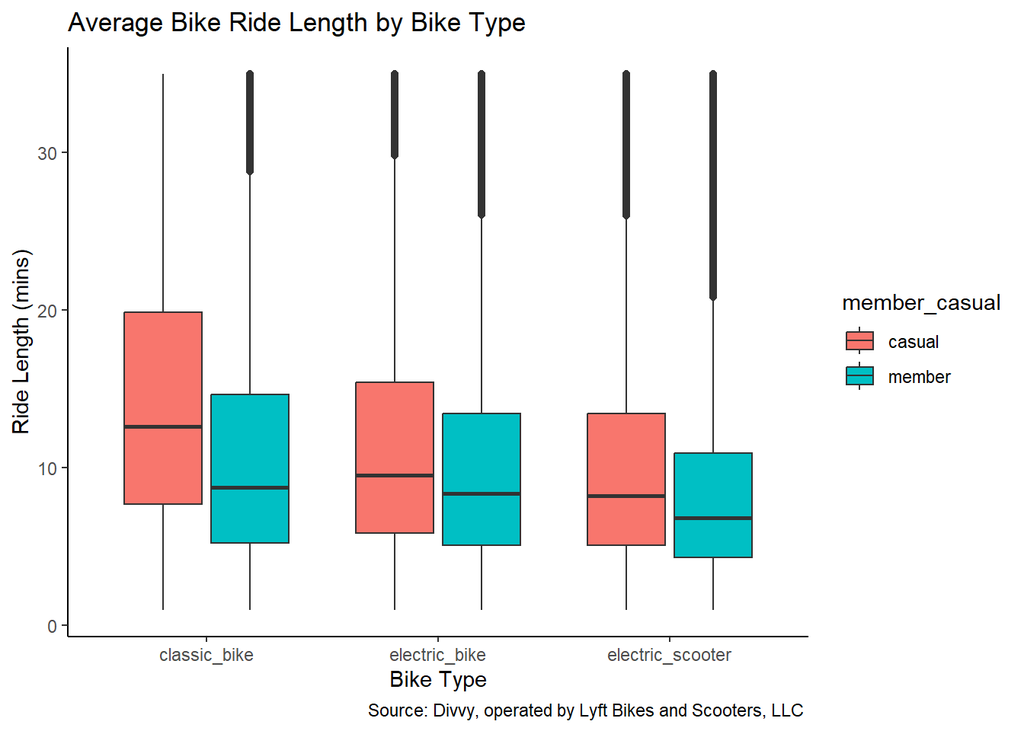

```r
ride_type_plot <- ggplot(bdfinal, aes(x = rideable_type, y = ride_length, fill = member_casual)) +
   geom_boxplot() +
   labs(
      title = "Average Bike Ride Length by Bike Type",
      caption = "Source: Divvy, operated by Lyft Bikes and Scooters, LLC ",
      x = "Bike Type",
      y = "Ride Length (mins)"
    ) +
   theme_classic()
ride_type_plot
```

```r
ggsave("problem5a.jpeg")
```

## Created a pipe/summary table of the number of rides per bike type for both casual and annual members.

```r
type_stats2 <- bdfinal %>%
  group_by(member_casual) %>%
  count(rideable_type, name = "n_rides")
type_stats2
```

```
## # A tibble: 6 × 3
## # Groups:   member_casual [2]
##   member_casual rideable_type    n_rides
##   <chr>         <chr>              <int>
## 1 casual        classic_bike      768792
## 2 casual        electric_bike     959042
## 3 casual        electric_scooter   77625
## 4 member        classic_bike     1705183
## 5 member        electric_bike    1791264
## 6 member        electric_scooter   55764
```

## Created a bar graph for total number of rides per bike type for both casual riders and member riders.

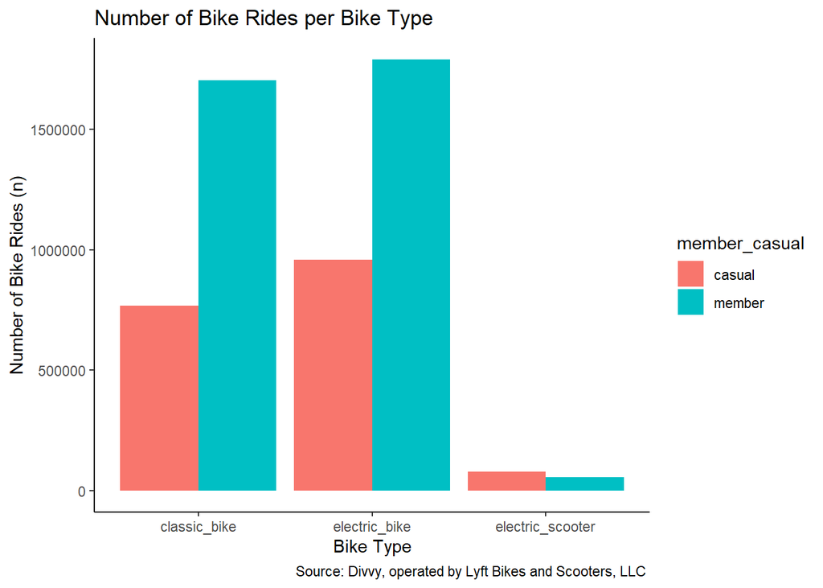

```r
type_num_plot <- ggplot(type_stats2, aes(x = rideable_type, y = n_rides, fill = member_casual)) +
   geom_bar(stat = "identity", position = "dodge") +
   labs(
      title = "Number of Bike Rides per Bike Type",
      caption = "Source: Divvy, operated by Lyft Bikes and Scooters, LLC ",
      x = "Bike Type",
      y = "Number of Bike Rides (n)"
    ) +
   theme_classic()
type_num_plot
```

```r
ggsave("problem5b.jpeg")
```

## Created 2 pipes to find the top 10 starting locations and the top 10 ending locations for casual riders. I will note the missing values in my final presentation.

```r
top_ten_cas <- subset(casualset, select=c(start_station_name, start_lat, start_lng))

top_ten_cs <- top_ten_cas %>%
  count(start_station_name, name = "n_rides")

top_ten_cstart <- top_ten_cas %>%
  left_join(top_ten_cs, by = "start_station_name") %>%
  distinct(start_station_name, .keep_all = TRUE) %>%
  arrange(desc(n_rides))
top_ten_cstart <- top_ten_cstart[1:11, ]
print(top_ten_cstart)
```

```
##                    start_station_name start_lat start_lng n_rides
## 1                                      41.79000 -87.62000  352648
## 2             Streeter Dr & Grand Ave  41.89228 -87.61204   33370
## 3   DuSable Lake Shore Dr & Monroe St  41.88096 -87.61674   22197
## 4  DuSable Lake Shore Dr & North Blvd  41.91172 -87.62680   18071
## 5               Michigan Ave & Oak St  41.90096 -87.62378   16198
## 6                      Shedd Aquarium  41.86723 -87.61536   15707
## 7                     Millennium Park  41.88103 -87.62408   14618
## 8                 Theater on the Lake  41.92628 -87.63083   12856
## 9                      Dusable Harbor  41.88698 -87.61281   12624
## 10              Wells St & Concord Ln  41.91213 -87.63466   10464
## 11                  Clark St & Elm St  41.90297 -87.63128    9844
```

```r
top_ten_cae <- subset(casualset, select=c(end_station_name, end_lat, end_lng))

top_ten_ce <- top_ten_cae %>%
  count(end_station_name, name = "n_rides")

top_ten_cend <- top_ten_cae %>%
  left_join(top_ten_ce, by = "end_station_name") %>%
  distinct(end_station_name, .keep_all = TRUE) %>%
  arrange(desc(n_rides))
top_ten_cend <- top_ten_cend[1:11, ]
print(top_ten_cend)
```

```
##                      end_station_name  end_lat   end_lng n_rides
## 1                                     41.78000 -87.58000  376423
## 2             Streeter Dr & Grand Ave 41.89228 -87.61204   35330
## 3  DuSable Lake Shore Dr & North Blvd 41.91172 -87.62680   20292
## 4   DuSable Lake Shore Dr & Monroe St 41.88096 -87.61674   19819
## 5               Michigan Ave & Oak St 41.90096 -87.62378   16691
## 6                     Millennium Park 41.88103 -87.62408   16427
## 7                      Shedd Aquarium 41.86723 -87.61536   14136
## 8                 Theater on the Lake 41.92628 -87.63083   12674
## 9                      Dusable Harbor 41.88698 -87.61281   11020
## 10              Wells St & Concord Ln 41.91213 -87.63466   10415
## 11                  Wells St & Elm St 41.90322 -87.63432    9578
```

## Found just how many missing casual ride start and end locations were missing compared to the casual data set and the overall data set.

```r
352648 / 1805459
```

```
## [1] 0.1953232
```

```r
352648 / 5357670
```

```
## [1] 0.06582115
```

```r
376423 / 1805459
```

```
## [1] 0.2084916
```

```r
376423 / 5357670
```

```
## [1] 0.07025871
```

## Created 2 pipes to find the top 10 starting locations and the top 10 ending locations for member riders. I will note the missing values in my final presentation.

```r
top_ten_mas <- subset(memberset, select=c(start_station_name, start_lat, start_lng))

top_ten_ms <- top_ten_mas %>%
  count(start_station_name, name = "n_rides")

top_ten_mstart <- top_ten_mas %>%
  left_join(top_ten_ms, by = "start_station_name") %>%
  distinct(start_station_name, .keep_all = TRUE) %>%
  arrange(desc(n_rides))
top_ten_mstart <- top_ten_mstart[1:11, ]
print(top_ten_mstart)
```

```
##              start_station_name start_lat start_lng n_rides
## 1                                41.96000 -87.65000  617476
## 2      Kingsbury St & Kinzie St  41.88918 -87.63851   28688
## 3  Clinton St & Washington Blvd  41.88338 -87.64117   27568
## 4       Clinton St & Madison St  41.88275 -87.64119   24205
## 5             Clark St & Elm St  41.93254 -87.63196   23837
## 6         Wells St & Concord Ln  41.91213 -87.63466   20424
## 7             Wells St & Elm St  41.90322 -87.63432   20003
## 8     Clinton St & Jackson Blvd  41.87832 -87.64098   19469
## 9        State St & Chicago Ave  41.89662 -87.62858   18531
## 10     University Ave & 57th St  41.79148 -87.59986   18218
## 11        Dearborn St & Erie St  41.89399 -87.62932   17945
```

```r
top_ten_mae <- subset(memberset, select=c(end_station_name, end_lat, end_lng))

top_ten_me <- top_ten_mae %>%
  count(end_station_name, name = "n_rides")

top_ten_mend <- top_ten_mae %>%
  left_join(top_ten_me, by = "end_station_name") %>%
  distinct(end_station_name, .keep_all = TRUE) %>%
  arrange(desc(n_rides))
top_ten_mend <- top_ten_mend[1:11, ]
print(top_ten_mend)
```

```
##                end_station_name  end_lat   end_lng n_rides
## 1                               41.98000 -87.67000  593251
## 2      Kingsbury St & Kinzie St 41.88918 -87.63851   28886
## 3  Clinton St & Washington Blvd 41.88338 -87.64117   28592
## 4       Clinton St & Madison St 41.88275 -87.64119   25605
## 5             Clark St & Elm St 41.90297 -87.63128   24072
## 6         Wells St & Concord Ln 41.91213 -87.63466   20627
## 7             Wells St & Elm St 41.90322 -87.63432   19955
## 8     Clinton St & Jackson Blvd 41.87832 -87.64098   19876
## 9        State St & Chicago Ave 41.89662 -87.62858   19265
## 10     University Ave & 57th St 41.79148 -87.59986   18653
## 11        Canal St & Madison St 41.88241 -87.63977   17961
```

## Found just how many missing member ride start and end locations were missing compared to the member data set and the overall data set.

```r
617476 / 3552211
```

```
## [1] 0.1738286
```

```r
617476 / 5357670
```

```
## [1] 0.1152508
```

```r
593251 / 3552211
```

```
## [1] 0.1670089
```

```r
593251 / 5357670
```

```
## [1] 0.1107293
```

## Some of the casual locations are present in both lists. Combined them into a single list to make it easy.

```r
top_ten_start_ccut <- top_ten_cstart[2:11,]
top_ten_end_ccut <- top_ten_cend[11,]
top_ten_overallc <- bind_rows(top_ten_start_ccut, top_ten_end_ccut)
print(top_ten_overallc)
```

```
##                    start_station_name start_lat start_lng n_rides
## 1             Streeter Dr & Grand Ave  41.89228 -87.61204   33370
## 2   DuSable Lake Shore Dr & Monroe St  41.88096 -87.61674   22197
## 3  DuSable Lake Shore Dr & North Blvd  41.91172 -87.62680   18071
## 4               Michigan Ave & Oak St  41.90096 -87.62378   16198
## 5                      Shedd Aquarium  41.86723 -87.61536   15707
## 6                     Millennium Park  41.88103 -87.62408   14618
## 7                 Theater on the Lake  41.92628 -87.63083   12856
## 8                      Dusable Harbor  41.88698 -87.61281   12624
## 9               Wells St & Concord Ln  41.91213 -87.63466   10464
## 10                  Clark St & Elm St  41.90297 -87.63128    9844
## 11                               <NA>        NA        NA    9578
##     end_station_name  end_lat   end_lng
## 1               <NA>       NA        NA
## 2               <NA>       NA        NA
## 3               <NA>       NA        NA
## 4               <NA>       NA        NA
## 5               <NA>       NA        NA
## 6               <NA>       NA        NA
## 7               <NA>       NA        NA
## 8               <NA>       NA        NA
## 9               <NA>       NA        NA
## 10              <NA>       NA        NA
## 11 Wells St & Elm St 41.90322 -87.63432
```

## Some of the member locations are present in both lists. Combined them into a single list to make it easy.

```r
top_ten_start_mcut <- top_ten_mstart[2:11,]
top_ten_end_mcut <- top_ten_mend[11,]
top_ten_overallm <- bind_rows(top_ten_start_mcut, top_ten_end_mcut)
print(top_ten_overallm)
```

```
##              start_station_name start_lat start_lng n_rides
## 1      Kingsbury St & Kinzie St  41.88918 -87.63851   28688
## 2  Clinton St & Washington Blvd  41.88338 -87.64117   27568
## 3       Clinton St & Madison St  41.88275 -87.64119   24205
## 4             Clark St & Elm St  41.93254 -87.63196   23837
## 5         Wells St & Concord Ln  41.91213 -87.63466   20424
## 6             Wells St & Elm St  41.90322 -87.63432   20003
## 7     Clinton St & Jackson Blvd  41.87832 -87.64098   19469
## 8        State St & Chicago Ave  41.89662 -87.62858   18531
## 9      University Ave & 57th St  41.79148 -87.59986   18218
## 10        Dearborn St & Erie St  41.89399 -87.62932   17945
## 11                         <NA>        NA        NA   17961
##         end_station_name  end_lat   end_lng
## 1                   <NA>       NA        NA
## 2                   <NA>       NA        NA
## 3                   <NA>       NA        NA
## 4                   <NA>       NA        NA
## 5                   <NA>       NA        NA
## 6                   <NA>       NA        NA
## 7                   <NA>       NA        NA
## 8                   <NA>       NA        NA
## 9                   <NA>       NA        NA
## 10                  <NA>       NA        NA
## 11 Canal St & Madison St 41.88241 -87.63977
```

[figure not shown]

```r
register_google(key = "AIzaSyCkk6Us7Qh_mcA5eHgNWKaNcpSiecYsveM")

chicagom<- c(lon = -87.640, lat = 41.865)
chicago_mapm <- get_map(location = chicagom, zoom = 12, source = "google", maptype = "terrain")
map_plot <- ggmap(chicago_mapm) +
  geom_point(data = top_ten_overallm, aes(x = start_lng, y = start_lat), color = "blue", size = 2.5) +
  geom_point(data = top_ten_overallm, aes(x = end_lng, y = end_lat), color = "blue", size = 2.5) +
  xlab("Longitude") +
  ylab("Latitude") +
  ggtitle("Map of Top 10 Starting and Ending Locations for Member Rides") +
  labs(caption = "Source: Divvy, operated by Lyft Bikes and Scooters, LLC ") +
  theme_minimal()
map_plot
```

```r
ggsave("problem6a.jpeg")
```

## Created a plot that displays the top 10 start locations and the top 10 end locations for casual riders.

[figure not shown]

```r
register_google(key = "AIzaSyCkk6Us7Qh_mcA5eHgNWKaNcpSiecYsveM")

chicagoc<- c(lon = -87.625, lat = 41.897)
chicago_mapc <- get_map(location = chicagoc, zoom = 13, source = "google", maptype = "terrain")
map_plot <- ggmap(chicago_mapc) +
  geom_point(data = top_ten_overallc, aes(x = start_lng, y = start_lat), color = "red", size = 2.5) +
  geom_point(data = top_ten_overallc, aes(x = end_lng, y = end_lat), color = "red", size = 2.5) +
  xlab("Longitude") +
  ylab("Latitude") +
  ggtitle("Map of Top 10 Starting and Ending Locations for Casual Rides") +
  labs(caption = "Source: Divvy, operated by Lyft Bikes and Scooters, LLC ") +
  theme_minimal()
map_plot
```

```r
ggsave("problem6b.jpeg")
```